# Figures of the maternal T1D methylation analysis

Raffael Ott

2025-03-24

## 0.2 Figure 1a

Manhattan plot showing the −log10(P) of the associations between the children’s blood DNA methylation status of individual CpG sites across the autosomal chromosomes (1‒22) and maternal T1D status (adjusted linear regression, two-sided).

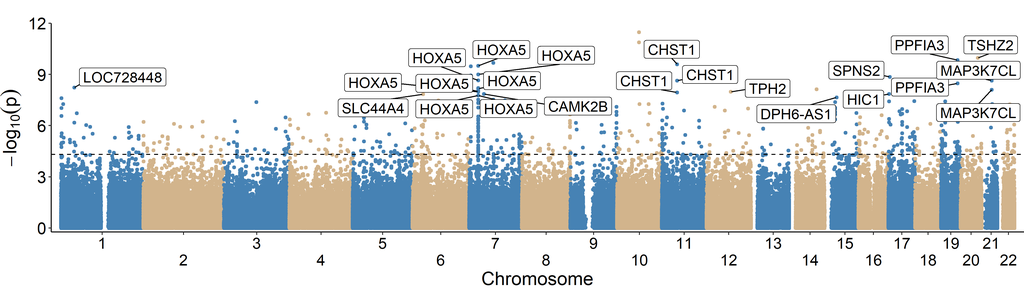

```r
# Figure 1a

plot_df <- meta_cpgs %>%
  group_by(chr) %>%
  # Compute chromosome size
  summarise(chrlength = max(pos)) %>%
  # Calculate cumulative position of each chromosome
  mutate(cumulativechrlength = cumsum(as.numeric(chrlength))-chrlength) %>%
  dplyr::select(-chrlength) %>%
  # Temporarily add the cumulative length of each chromosome to the initial
  # dataset
  left_join(meta_cpgs, ., by = c("chr" = "chr")) %>%
  # Sort by chr then position
  arrange(chr, pos) %>%
  # Add the position to the cumulative chromosome length to get the position of
  # this probe relative to all other probes
  mutate(rel_pos = pos + cumulativechrlength) %>%
  # Annotate genes to top CpGs
  mutate(logged_p = -log10(p)) %>%
  mutate(is_annotate = ifelse(-log10(p) > 7.65, "yes", "no")) %>%
  dplyr::select(-cumulativechrlength)
# Create axis data
axis_df <- plot_df %>%
  group_by(chr) %>%
  summarize(chr_center = (max(rel_pos) + min(rel_pos)) / 2)
# Get maximal log p-value
maxp <- ceiling(max(plot_df$logged_p, na.rm = TRUE))

# Manhattan plot
fig1a <- ggplot() +
  geom_point(data = plot_df,
             aes(x = rel_pos, y = logged_p, color = as.factor(chr)),
             size = 1.3) +
  scale_color_manual(values = rep(c("steelblue", "tan"), nrow(axis_df))) +
  scale_x_continuous(labels = axis_df$chr,
                     breaks = axis_df$chr_center,
                     expand = expansion(mult = 0.01),
                     guide = guide_axis(n.dodge = 2)) +
  scale_y_continuous(limits = c(0, maxp),
                     expand = expansion(mult = c(0.02, 0))) +
  geom_hline(yintercept = -log10(4.8e-05),
             color = "black",
             linetype = "dashed",
             linewidth = 0.5) +
  labs(x = "Chromosome",
       y = bquote(-log[10](p))) +
  theme_classic() +
  theme(legend.position = "none",
        axis.title.x = element_text(size=18,
                                    color = "black"),
        axis.title.y = element_text(size=18,
                                    color = "black"),
        axis.text.x =  element_text(size=15,
                                    color = "black"),
        axis.text.y =  element_text(size=16,
                                    color = "black"),
        plot.margin = unit(c(0.8,0,0,0), "cm")) +
  geom_label_repel(data = subset(plot_df,
                               is_annotate == "yes"),
                   aes(x = rel_pos, y = logged_p, label = label),
                   size = 5,
                   min.segment.length = unit(0, 'lines'),
                   nudge_y = .2,
                   max.overlaps = Inf)

print(fig1a)
```

## 0.3 Figure 1b

Higher-magnification view of (Fig. 1a) including the HOXA gene cluster at chromosome 7p15.

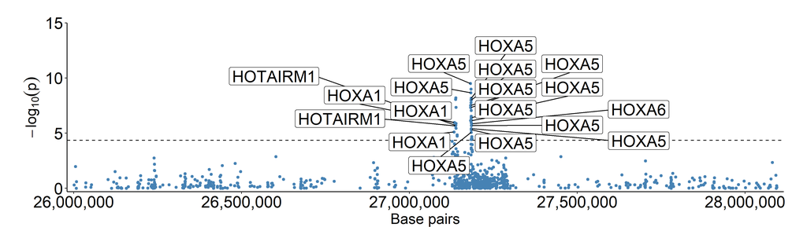

```r
# Figure 1b

plot_df <- meta_cpgs_hoxa %>%
  group_by(chr) %>%
  # Compute chromosome size
  summarise(chrlength = max(pos)) %>%
  # Calculate cumulative position of each chromosome
  mutate(cumulativechrlength = cumsum(as.numeric(chrlength))-chrlength) %>%
  dplyr::select(-chrlength) %>%
  # Temporarily add the cumulative length of each chromosome to the initial
  # dataset
  left_join(meta_cpgs_hoxa, ., by = c("chr" = "chr")) %>%
  # Sort by chr then position
  arrange(chr, pos) %>%
  # Add the position to the cumulative chromosome length to get the position of
  # this probe relative to all other probes
  mutate(rel_pos = pos + cumulativechrlength) %>%
  # Annotate genes to top CpGs
  mutate(logged_p = -log10(p)) %>%
  mutate(is_annotate = ifelse(-log10(p) > 5, "yes", "no")) %>%
  dplyr::select(-cumulativechrlength)
# Create axis data
axis_df <- plot_df %>%
  group_by(chr) %>%
  summarize(chr_center = (max(rel_pos) + min(rel_pos)) / 2)
# Get maximal log p-value
maxp <- ceiling(max(plot_df$logged_p, na.rm = TRUE))

# Manhattan plot
fig1b <- ggplot() +
  geom_point(data = plot_df,
             aes(x = rel_pos, y = logged_p, color = as.factor(chr)),
             size = 1.3) +
  scale_color_manual(values = rep(c("steelblue", "tan"),
                                  nrow(axis_df))) +
  scale_x_continuous(expand = expansion(mult = 0.01),
                     labels = scales::comma) +
  scale_y_continuous(limits = c(0, 15),
                     expand = expansion(mult = c(0.02, 0))) +
  geom_hline(yintercept = -log10(4.4e-05), color = "black", linetype = "dashed",
             linewidth = 0.5) +
  labs(x = "Base pairs",
       y = bquote(-log[10](p))) +
  theme_classic() +
  theme(legend.position = "none",
        axis.title.x = element_text(size=18,
                                    color = "black"),
        axis.title.y = element_text(size=18,
                                    color = "black"),
        axis.text.x =  element_text(size=20,
                                    color = "black"),
        axis.text.y =  element_text(size=20,
                                    color = "black")
        ) +
  theme(plot.margin = unit(c(1,1,0,1), "cm")) +
  geom_label_repel(data = subset(plot_df,
                                 is_annotate == "yes"),
                   aes(x = rel_pos,
                       y = logged_p,
                       label=label),
                   size = 7,
                   min.segment.length = unit(0, 'lines'),
                   nudge_y = 1,
                   nudge_x = 10000,
                   max.overlaps = 36)

print(fig1b)
```

## 0.4 Figure 1c

Volcano plot showing −log10(P) against the effect estimates of the CpG analysis (change in methylation M-value by maternal T1D).

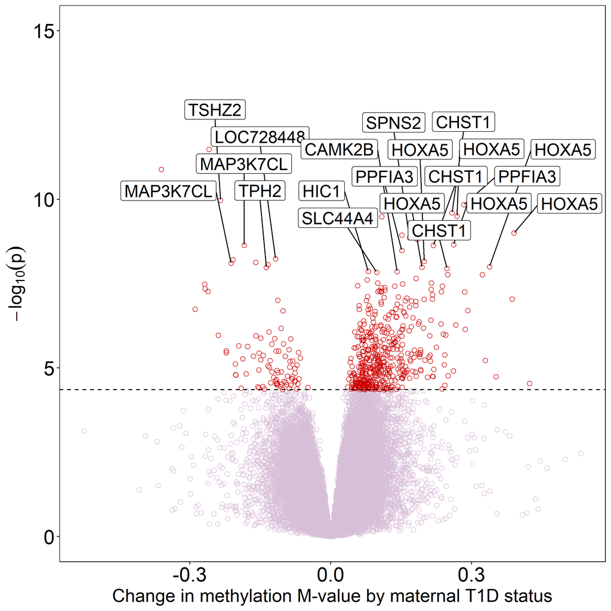

```r
# Figure 1c

vplot_cpgs <- meta_cpgs %>%
  mutate(is_annotate = ifelse(-log10(p) > 7.8, "yes", "no"))
possig<-vplot_cpgs %>%
  filter(BETA > 0 & PFDR < 0.05)
negsig<-vplot_cpgs %>%
  filter(BETA < 0 & PFDR < 0.05)

fig1c <- ggplot(data = vplot_cpgs,
                     aes(x = BETA, y = -log10(p))) +
  geom_point(data = vplot_cpgs,
             shape = 21,
             size = 2,
             color = "thistle") +
  geom_point(data = negsig,
             shape = 21,
             size = 2,
             color = "red3") +
  geom_point(data = possig,
             shape = 21,
             size = 2,
             color = "red3") +
  geom_hline(yintercept = -log10(4.4e-05),
             linetype = "dashed") +
  geom_label_repel(data = subset(vplot_cpgs,
                                 is_annotate == "yes"),
                   aes(x = BETA,
                       y = -log10(p),
                       label = label),
                   force = 2,
                   size = 6,
                   nudge_y = 2.5,
                   max.overlaps = Inf) +
  scale_y_continuous(limits = c(0, 15)) +
  labs(x = "Change in methylation M-value by maternal T1D status",
       y = bquote(-log[10](p))) +
  theme_bw() +
  theme(panel.border = element_rect(colour = "black", fill = NA,
                                    linewidth = 0.5),
        panel.grid.minor = element_blank(),
        panel.grid.major = element_blank(),
        axis.title.x = element_text(size=18,
                                    color = "black"),
        axis.title.y = element_text(size=18,
                                    color = "black"),
        axis.text.x =  element_text(size=20,
                                    color = "black"),
        axis.text.y =  element_text(size=20,
                                    color = "black")
        )

print(fig1c)
```

## 0.5 Figure 1d

Correlation of effect estimates between the individual studies (BABYDIAB/BABYDIET and POInT). Correlation (Pearson’s r, one-sided) of effect estimates of the 566 CpGs significantly associated with maternal type 1 diabetes (T1D) status. Each dot represents a CpG.

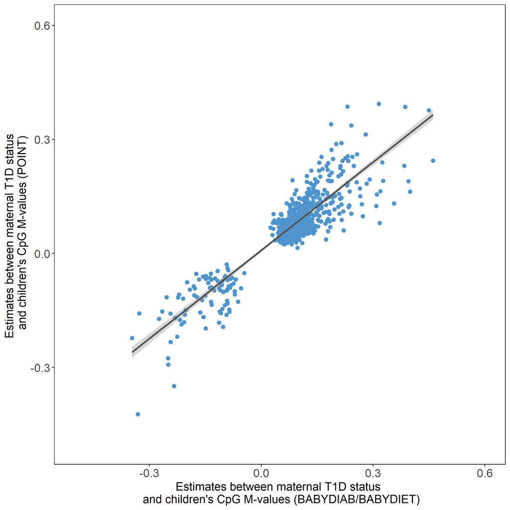

```r
# Figure 1d

ggsave <- function(..., bg = 'white') ggplot2::ggsave(..., bg = bg)
fig1d <- ggplot(Fig1d_data,
                       aes(x = Estimate_babydiabdiet,
                           y = Estimate_point)) +
  geom_point(color="steelblue3",
             size = 2) +
  geom_smooth(method = lm ,
              color = "grey30",
              fill = "grey60",
              se = TRUE) +
  theme_classic() +
  ylim(-0.5, 0.6) +
  xlim(-0.5, 0.6) +
  labs(x = "Estimates between maternal T1D status \n and children's CpG M-values (BABYDIAB/BABYDIET)",
       y = "Estimates between maternal T1D status \n and children's CpG M-values (POINT)") +
  theme_bw() +
  theme(panel.border = element_rect(colour = "black",
                                    fill = NA,
                                    size= 0.5),
        panel.grid.minor = element_blank(),
        panel.grid.major = element_blank(),
        axis.title = element_text(size = 14),
        axis.text =  element_text(size = 14))

print(fig1d)
```

## 0.6 Figure 1e

Manhattan plot showing the −log10(P) of the associations between the children’s differentially methylated regions (DMRs) and maternal T1D (adjusted linear regression, two-sided).

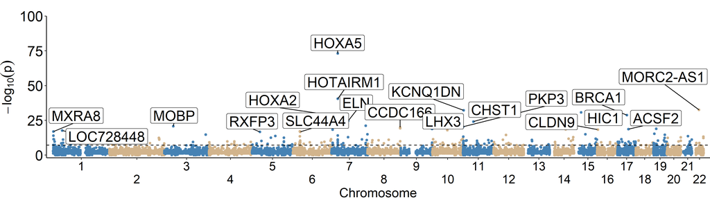

```r
# Figure 1e

plot_df <- meta_dmr %>%
  group_by(chr) %>%
  # Compute chromosome size
  summarise(chrlength = max(pos)) %>%
  # Calculate cumulative position of each chromosome
  mutate(cumulativechrlength = cumsum(as.numeric(chrlength))-chrlength) %>%
  dplyr::select(-chrlength) %>%
  # Temporarily add the cumulative length of each chromosome to the initial
  # dataset
  left_join(meta_dmr, ., by = c("chr" = "chr")) %>%
  # Sort by chr then position
  arrange(chr, pos) %>%
  # Add the position to the cumulative chromosome length to get the position of
  # this probe relative to all other probes
  mutate(rel_pos = pos + cumulativechrlength) %>%
  # Calculate the logged p-value too
  mutate(logged_p = -log10(p)) %>%
  mutate(is_annotate=ifelse(-log10(p) > 16, "yes", "no")) %>%
  dplyr::select(-cumulativechrlength)
# Create axis data
axis_df <- plot_df %>%
  group_by(chr) %>%
  summarize(chr_center = (max(rel_pos) + min(rel_pos)) / 2)
# Get maximal log p-value
maxp <- ceiling(max(plot_df$logged_p, na.rm = TRUE))

# Manhattan plot
fig1e <- ggplot() +
  geom_point(data = plot_df,
             aes(x = rel_pos, y = logged_p, color = as.factor(chr)),
             size = 1.3,
             position = position_dodge2(width = 0.09)) +
  scale_color_manual(values = rep(c("steelblue", "tan"), nrow(axis_df))) +
  scale_x_continuous(labels = axis_df$chr,
                     breaks = axis_df$chr_center,
                     expand = expansion(mult = 0.01),
                     guide = guide_axis(n.dodge = 2)) +
  scale_y_continuous(limits = c(0, 100),
                     position = "left",
                     expand = expansion(mult = c(0.02, 0)))  +
  geom_hline(yintercept = -log10(6.8e-08),
             color = "black",
             linetype = "dashed",
             linewidth = 0.5) +
  labs(x = "Chromosome",
       y = bquote(-log[10](p))) +
  theme_classic() +
  theme(legend.position = "none",
        axis.title.x = element_text(size=18,
                                    color = "black"),
        axis.title.y = element_text(size=18,
                                    color = "black"),
        axis.text.x =  element_text(size=17,
                                    color = "black"),
        axis.text.y =  element_text(size=20,
                                    color = "black"),
        plot.margin = unit(c(0.8,0,0,0), "cm")
        ) +
  geom_label_repel(data = subset(plot_df,
                                 is_annotate == "yes"),
                   aes(x = rel_pos,
                       y = logged_p,
                       label = gene),
                   size = 7,
                   min.segment.length = unit(0, 'lines'),
                   nudge_y = 7,
                   max.overlaps = Inf)

print(fig1e)
```

## 0.7 Figure 1f (upper)

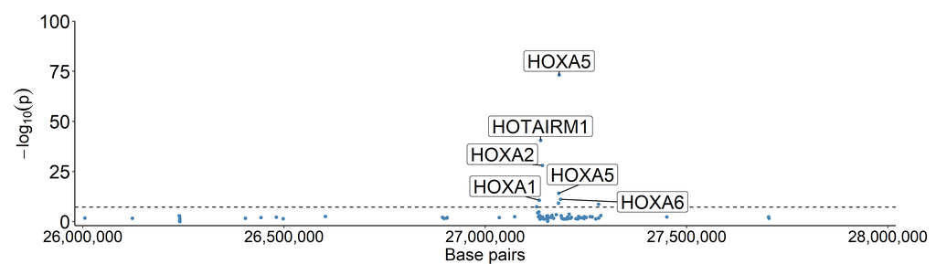

```r
# Figure 1f upper

plot_df <- meta_dmr_hoxa %>%
  group_by(chr) %>%
  # Compute chromosome size
  summarise(chrlength = max(pos)) %>%
  # Calculate cumulative position of each chromosome
  mutate(cumulativechrlength = cumsum(as.numeric(chrlength))-chrlength) %>%
  dplyr::select(-chrlength) %>%
  # Temporarily add the cumulative length of each chromosome to the initial
  # dataset
  left_join(meta_dmr_hoxa, ., by = c("chr" = "chr")) %>%
  # Sort by chr then position
  arrange(chr, pos) %>%
  # Add the position to the cumulative chromosome length to get the position of
  # this probe relative to all other probes
  mutate(rel_pos = pos + cumulativechrlength) %>%
  # Calculate the logged p-value too
  mutate(logged_p = -log10(p)) %>%
  mutate(is_annotate=ifelse(-log10(p) > 10, "yes", "no")) %>%
  dplyr::select(-cumulativechrlength)
# Create axis data
axis_df <- plot_df %>%
  group_by(chr) %>%
  summarize(chr_center = (max(rel_pos) + min(rel_pos)) / 2)
# Get maximal log p-value
maxp <- ceiling(max(plot_df$logged_p, na.rm = TRUE))

# Manhattan plot
fig1ft <- ggplot() +
  geom_point(data = plot_df,
             aes(x = rel_pos, y = logged_p, color = as.factor(chr)),
             size = 1.3,
             position = position_dodge2(width = 0.09)) +
  scale_color_manual(values = rep(c("steelblue"), nrow(axis_df))) +
  scale_x_continuous(limits = c(26000000, 28000000),
                     expand = expansion(mult = 0.01),
                     labels = scales::comma) +
  scale_y_continuous(limits = c(0, 100),
                     position = "left",
                     expand = expansion(mult = c(0.02, 0)))  +
  geom_hline(yintercept = -log10(6.8e-08),
             color = "black",
             linetype = "dashed",
             linewidth = 0.5) +
  labs(x = "Base pairs",
       y = bquote(-log[10](p))) +
  theme_classic() +
  theme(legend.position = "none",
        axis.title.x = element_text(size=18,
                                    color = "black"),
        axis.title.y = element_text(size=18,
                                    color = "black"),
        axis.text.x =  element_text(size=17,
                                    color = "black"),
        axis.text.y =  element_text(size=20,
                                    color = "black"),
        plot.margin = unit(c(0.8,1.5,0,0.5), "cm")
        ) +
  geom_label_repel(data = subset(plot_df,
                                 is_annotate == "yes"),
                   aes(x = rel_pos,
                       y = logged_p,
                       label = gene),
                   size = 7,
                   min.segment.length = unit(0, 'lines'),
                   nudge_y = 7,
                   max.overlaps = Inf)

print(fig1ft)
```

## 0.8 Figure 1f (lower)

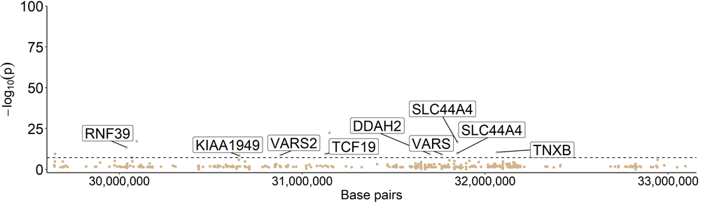

```r
# Figure 1g lower

plot_df <- meta_dmr_chr6 %>%
  group_by(chr) %>%
  # Compute chromosome size
  summarise(chrlength = max(pos)) %>%
  # Calculate cumulative position of each chromosome
  mutate(cumulativechrlength = cumsum(as.numeric(chrlength))-chrlength) %>%
  dplyr::select(-chrlength) %>%
  # Temporarily add the cumulative length of each chromosome to the initial
  # dataset
  left_join(meta_dmr_chr6, ., by=c("chr" = "chr")) %>%
  # Sort by chr then position
  arrange(chr, pos) %>%
  # Add the position to the cumulative chromosome length to get the position of
  # this probe relative to all other probes
  mutate(rel_pos = pos + cumulativechrlength) %>%
  # Calculate the logged p-value too
  mutate(logged_p = -log10(p)) %>%
  mutate(is_annotate = ifelse(-log10(p) > 7, "yes", "no")) %>%
  dplyr::select(-cumulativechrlength)
# Create axis data
axis_df <- plot_df %>%
  group_by(chr) %>%
  summarize(chr_center = (max(rel_pos) + min(rel_pos)) / 2)
# Get maximal log p-value
maxp <- ceiling(max(plot_df$logged_p, na.rm = TRUE))

# Manhattan plot
fig1fl <- ggplot() +
  geom_point(data = plot_df,
             aes(x = rel_pos, y = logged_p, color = as.factor(chr)),
             size = 1.3,
             position = position_dodge2(width = 0.09)) +
  scale_color_manual(values = rep(c("tan"), nrow(axis_df))) +
  scale_x_continuous(limits= c(29640000, 33120000),
                     expand = expansion(mult = 0.01),
                     labels = scales::comma) +
  scale_y_continuous(limits = c(0, 100), position = "left",
                     expand = expansion(mult = c(0.02, 0)))  +
  geom_hline(yintercept = -log10(6.8e-08),
             color = "black",
             linetype = "dashed",
             linewidth = 0.5) +
  labs(x = "Base pairs",
       y = bquote(-log[10](p))) +
  theme_classic() +
  theme(legend.position = "none",
        axis.title.x = element_text(size=18,
                                    color = "black"),
        axis.title.y = element_text(size=18,
                                    color = "black"),
        axis.text.x =  element_text(size=17,
                                    color = "black"),
        axis.text.y =  element_text(size=20,
                                    color = "black"),
        plot.margin = unit(c(0.3,1,0,0), "cm")
        ) +
  geom_label_repel(data = subset(plot_df,
                                 is_annotate == "yes"),
                   aes(x = rel_pos,
                       y = logged_p,
                       label = gene),
                   size = 7,
                   min.segment.length = unit(0, 'lines'),
                   nudge_y = 7,
                   max.overlaps = Inf)

print(fig1fl)
```

## 0.9 Figure 1g

Volcano plot showing −log10(P) against the effect estimates of the DMRs analysis (change in methylation M-value by maternal T1D).

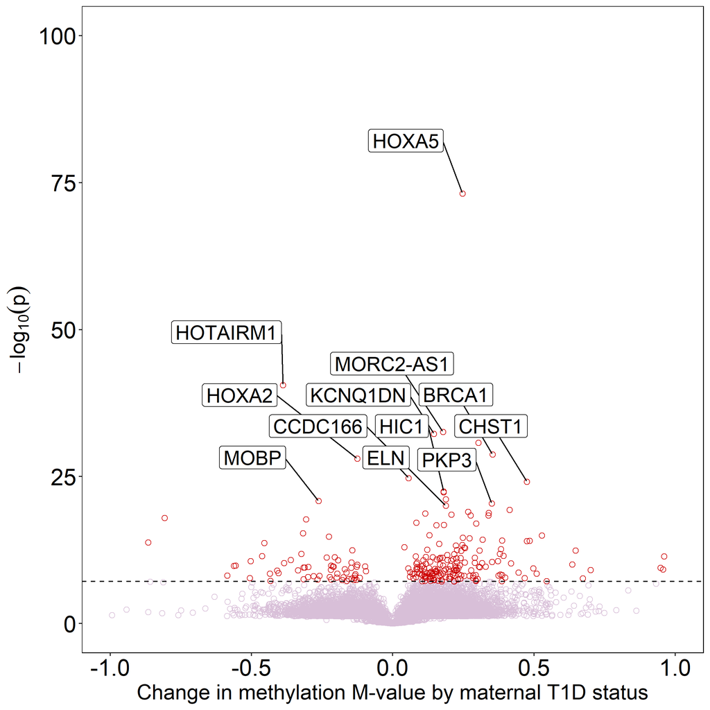

```r
# Figure 1g

fig1g <- ggplot(data = vplot_dmr,
                     aes(x = estimate,
                         y = -log10(p))) +
  geom_point(data = vplot_dmr,
             shape = 21,
             size = 2,
             color = "thistle") +
  geom_point(data = negsig,
             shape = 21,
             size = 2,
             color = "red3") +
  geom_point(data = possig,
             shape = 21,
             size = 2,
             color = "red3") +
  geom_hline(yintercept = -log10(6.8e-08),
             linetype = "dashed") +
  geom_label_repel(data = subset(vplot_dmr,
                                 is_annotate == "yes"),
                   aes(x = estimate,
                       y = -log10(p),
                       label = gene),
                   force = 2,
                   size = 6,
                   nudge_y = 9,
                   nudge_x = -0.2,
                   max.overlaps = 30) +
  scale_y_continuous(limits = c(0, 100),
                     breaks = c(0,25,50,75,100)) +
  scale_x_continuous(limits = c(-1, 1,2),
                     breaks = c(-1,-0.5,0,0.5,1)) +
  labs(x = "Change in methylation M-value by maternal T1D status",
       y = bquote(-log[10](p))) +
  theme_bw() +
  theme(panel.border = element_rect(colour = "black",
                                    fill = NA,
                                    linewidth = 0.5),
        panel.grid.minor = element_blank(),
        panel.grid.major = element_blank(),
        axis.title.x = element_text(size=18,
                                    color = "black"),
        axis.title.y = element_text(size=18,
                                    color = "black"),
        axis.text.x =  element_text(size=20,
                                    color = "black"),
        axis.text.y =  element_text(size=20,
                                    color = "black"))

print(fig1g)
```

## 0.10 Figure 1h

Correlation (Pearson’s r, one-sided) of effect estimates of the 238 differentially methylated regions (DMRs) significantly associated with maternal T1D status.

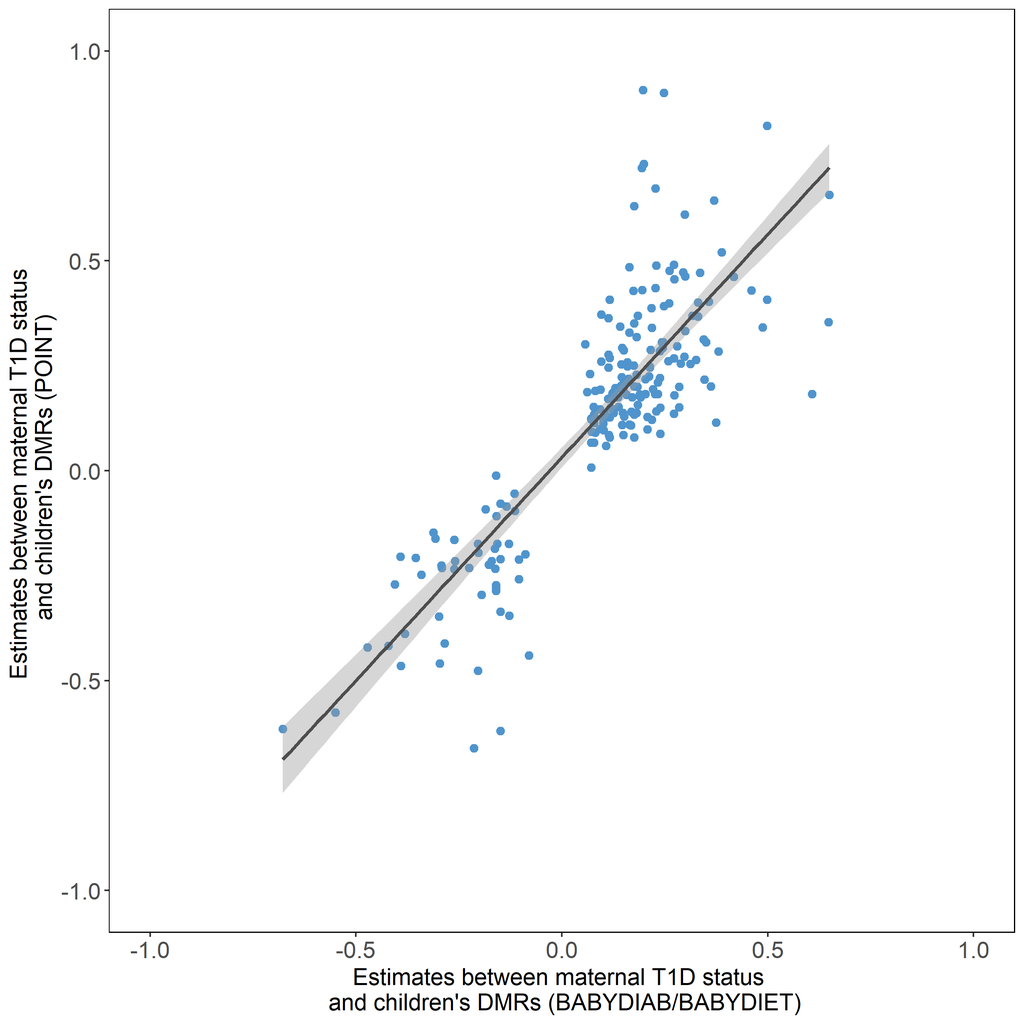

```r
# Figure 1h

ggsave <- function(..., bg = 'white') ggplot2::ggsave(..., bg = bg)

fig1h <- ggplot(fig1h_data,
                       aes(x = Estimate_babydiabdiet,
                           y = Estimate_point)) +
  geom_point(color="steelblue3",
             size = 2) +
  geom_smooth(method = lm ,
              color = "grey30",
              fill = "grey60",
              se = TRUE) +
  theme_classic() +
  ylim(-1, 1) +
  xlim(-1, 1) +
  labs(x = "Estimates between maternal T1D status \n and children's DMRs (BABYDIAB/BABYDIET)",
       y = "Estimates between maternal T1D status \n and children's DMRs (POINT)") +
  theme_bw() +
  theme(panel.border = element_rect(colour = "black",
                                    fill = NA,
                                    size= 0.5),
        panel.grid.minor = element_blank(),
        panel.grid.major = element_blank(),
        axis.title = element_text(size = 14),
        axis.text =  element_text(size = 14))

print(fig1h)
```

## 0.11 Figure 1i (created in Inkscape)

Summary of the epigenome-wide CpG and DMR analyses (please refer to the manuscript).

## 0.13 Figure 2a

Frequency of maternal T1D-associated CpG locations in major gene regions compared with all CpGs included in the meta-analyses.

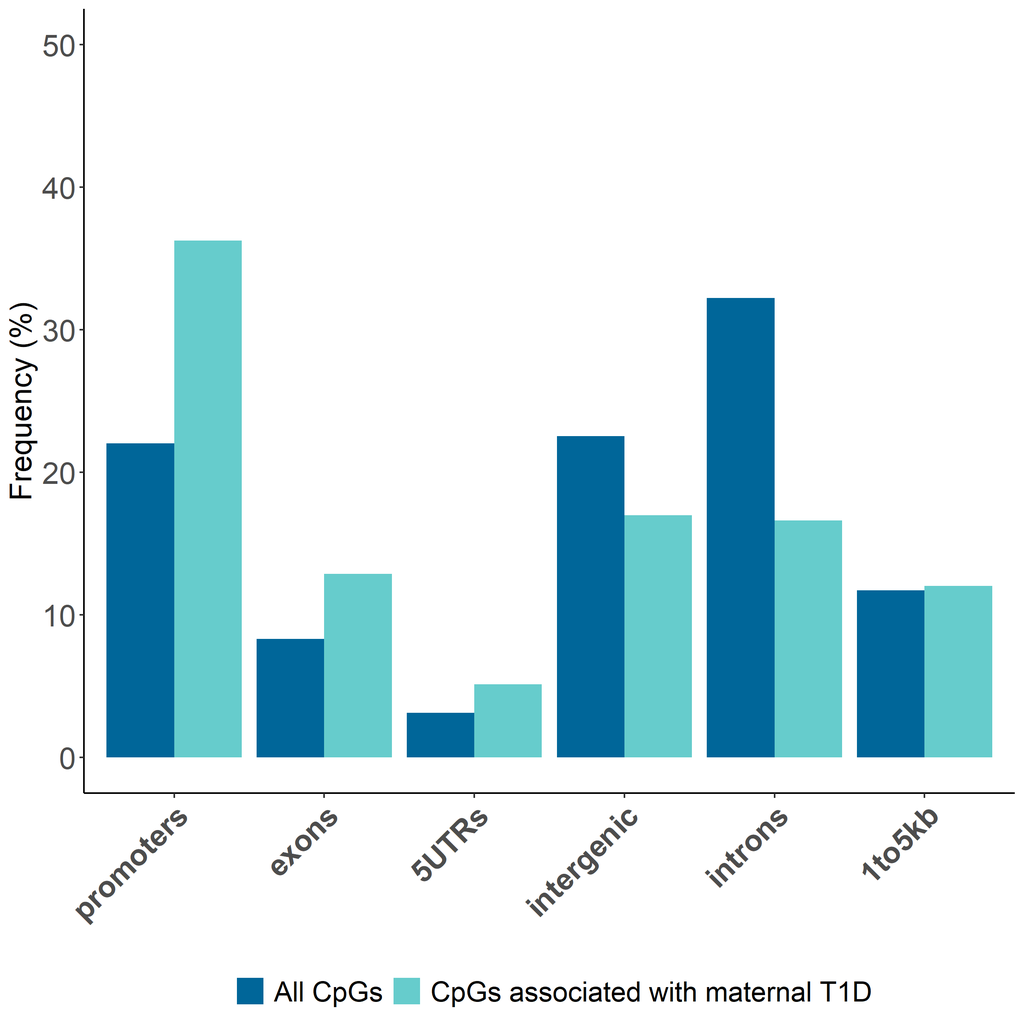

```r
# Figure 2a

# Create category levels
levels <- c("promoters",
            "exons",
            "5UTRs",
            "intergenic",
            "introns",
            "1to5kb")
# plot
fig2a <- ggplot(genomic_regions, aes(x = Region,
                                     y = percent,
                                     fill = group)) +
  geom_bar(position = "dodge",
           stat = "identity") +
  scale_fill_manual(values = c("#006699","#66CCCC")) +
  xlab("") +
  ylab("Frequency (%)") +
  labs(fill = "") +
  scale_x_discrete(limits = levels) +
  ylim(0, 50) +
  theme_classic() +
  theme(
    axis.text = element_text(size = 18),
    axis.text.x = element_text(face = "bold",
                               size = 18,
                               angle = 45,
                               hjust = 1),
    axis.title.y = element_text(size = 18),
    legend.position = "bottom",
    legend.text = element_text(size = rel(1.5)))

print(fig2a)
```

## 0.14 Figure 2b

Frequency of maternal T1D-associated CpG locations according to CpG island categories compared with all CpGs included in the meta-analyses.

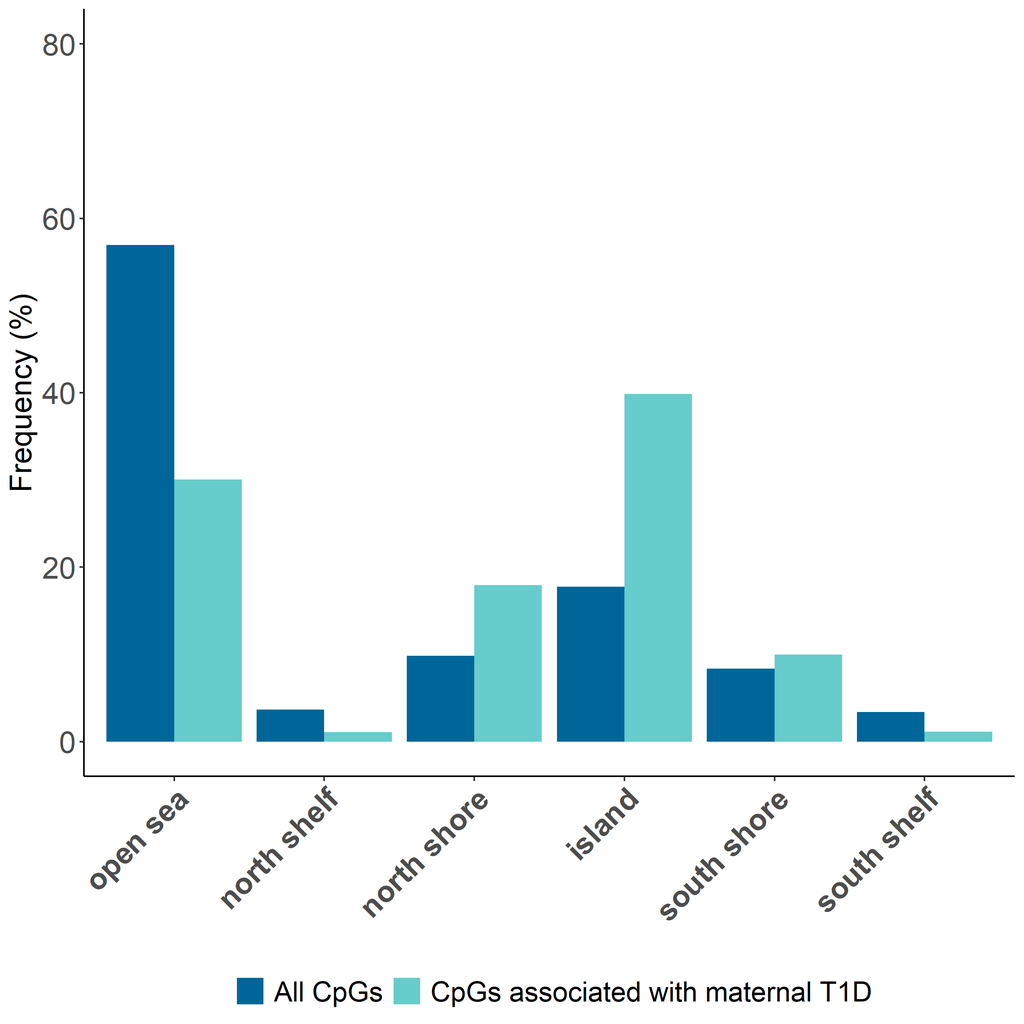

```r
# Figure 2b

# Create category levels
levels <- c("open sea",
            "north shelf",
            "north shore",
            "island",
            "south shore",
            "south shelf")
# plot
fig2b <- ggplot(islands_data,
                aes(x = region,
                    y = percent,
                    fill = group)) +
  geom_bar(position = "dodge",
           stat = "identity") +
  scale_fill_manual(values = c("#006699","#66CCCC")) +
  xlab("") +
  ylab("Frequency (%)") +
  labs(fill = "") +
  scale_x_discrete(limits = levels) +
  ylim(0, 80) +
  theme_classic() +
  theme(
    axis.text = element_text(size = 18),
    axis.text.x = element_text(face = "bold",
                               size = 18,
                               angle = 45,
                               hjust = 1),
    axis.title.y = element_text(size = 18),
    legend.position = "bottom",
    legend.text = element_text(size = rel(1.5)))

print(fig2b)
```

## 0.15 Figure 2c

Enrichments for regulatory elements of maternal T1D-associated CpG locations across specific immune cell types and tissues with relevance for T1D compared with all CpGs included in the meta-analysis (white tiles represent no enrichments; hypergeometric test, one-sided).

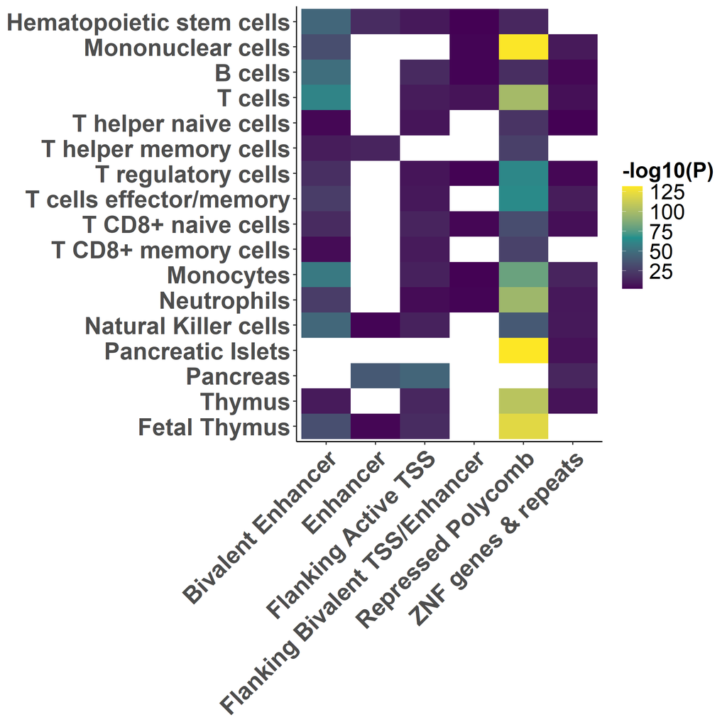

```r
# Figure 2c

# Create category levels
tissue_levels <- c("Fetal Thymus",
                            "Thymus",
                            "Pancreas",
                            "Pancreatic Islets",
                            "Natural Killer cells",
                            "Neutrophils",
                            "Monocytes",
                            "T CD8+ memory cells",
                            "T CD8+ naive cells",
                            "T cells effector/memory",
                            "T regulatory cells",
                            "T helper memory cells",
                            "T helper naive cells",
                            "T cells",
                            "B cells",
                            "Mononuclear cells",
                            "Hematopoietic stem cells")
# plot
fig2c <- ggplot(data = chrom_data,
                aes(x = Mark,
                    y = factor(Epigenome,
                    level = tissue_levels))) +
  geom_tile(aes(fill = -log10(Enrichment_Pval))) +
  scale_fill_gradientn(colors = viridis(3),
                       na.value = "white") +
  scale_y_discrete(limits = tissue_levels,
                   labels = function(x) str_wrap(x, width = 50)) +
  theme_classic() +
  theme(axis.text.y = element_text(size = 20,
                                   face = "bold"),
        axis.text.x = element_text(size = 20,
                                   face = "bold",
                                   angle = 45,
                                   hjust = 1),
        legend.text = element_text(size = 18),
        legend.title = element_text(size = 18,
                                    face = "bold"),
        legend.spacing.y = unit(0.5, 'cm')) +
  labs(
    x = NULL,
    y = NULL,
    fill = '-log10(P)')

print(fig2c)
```

## 0.16 Figure 2d

Transcription factor binding motif analysis of maternal T1D-associated CpGs (Fisher’s exact test, two-sided).

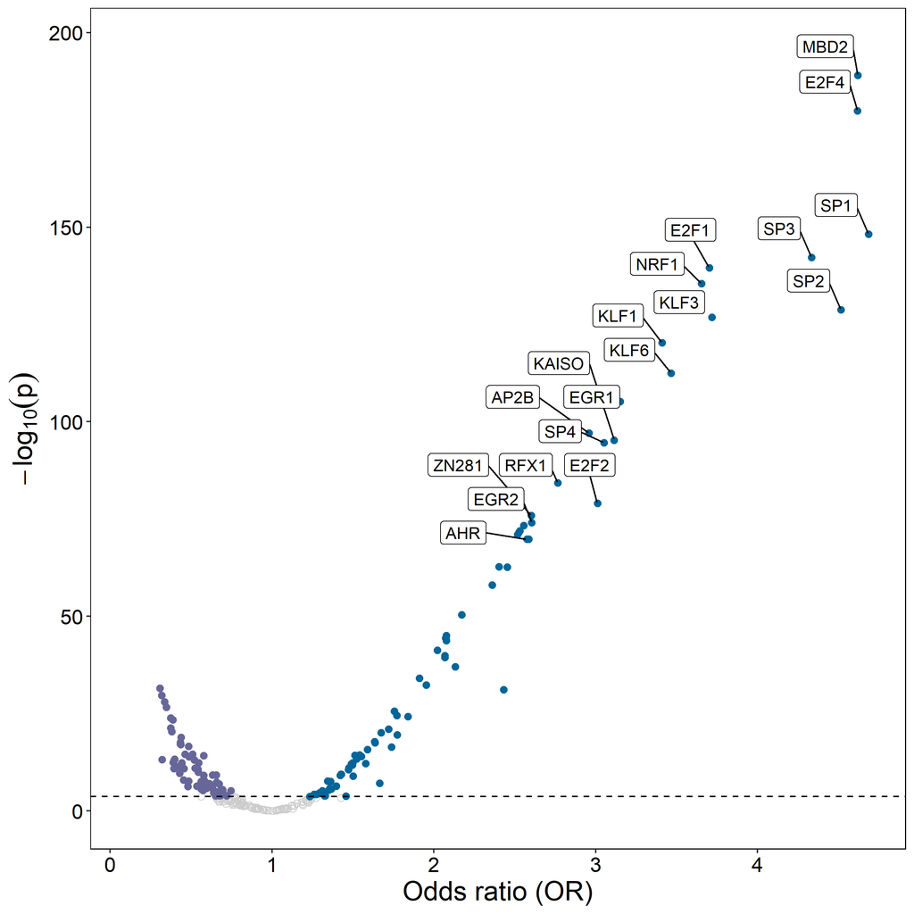

```r
# Figure 2d

fig2d <- ggplot(data = motifs_data,
                     aes(x = OR,
                         y = -log10(`p.value`))) +
  geom_point(data = motifs_data,
             shape = 21,
             size = 2,
             color = "#CCCCCC") +
  geom_point(data = negsig,
             shape = 16,
             size = 2,
             color = "#666699") +
  geom_point(data = possig,
             shape = 16,
             size = 2,
             color = "#006699") +
  geom_hline(yintercept = -log10(0.05/265), #Bonferroni correction for 265 TFs
             linetype = "dashed") +
  geom_label_repel(data = subset(motifs_data,
                                 is_annotate = "yes"),
                   aes(x = OR,
                       y = -log10(`p.value`),
                       label = annotate),
                   force = 2,
                   nudge_y = 7.5,
                   nudge_x = -0.2,
                   max.overlaps = 30) +
  labs(x = "Odds ratio (OR)",
       y = bquote(-log[10](p))) +
  theme_bw() +
  theme(panel.border = element_rect(colour = "black",
                                    fill = NA,
                                    size= 0.5),
        panel.grid.minor = element_blank(),
        panel.grid.major = element_blank(),
        axis.title.x = element_text(size=18,
                                    color = "black"),
        axis.title.y = element_text(size=18,
                                    color = "black"),
        axis.text.x =  element_text(size=14,
                                    color = "black"),
        axis.text.y =  element_text(size=14,
                                    color = "black"))

print(fig2d)
```

## 0.17 Figure 3

Identified CpGs target T1D susceptibility genes according to eQTM data of children’s blood. a, Gene ontology (GO) analysis of all eQTM gene targets of the maternal T1D-associated CpGs. Only the top 10 ontologies are shown. Supplementary Table S8 lists all enriched terms (Fisher’s exact test, one-sided, PFDR < 0.05). b, Observed effects of CpGs (in terms of increase in methylation) on the expression of T1D susceptibility genes (positive or negative association) according to cis-eQTM data and effects on gene expression based on changes in methylation of the corresponding CpGs associated with exposure to maternal T1D.

## 0.18 Figure 3a

Gene ontology (GO) analysis of all eQTM gene targets of the maternal T1D-associated CpGs. Only the top 10 ontologies are shown. Supplementary Table S8 lists all enriched terms (Fisher’s exact test, one-sided, PFDR < 0.05).

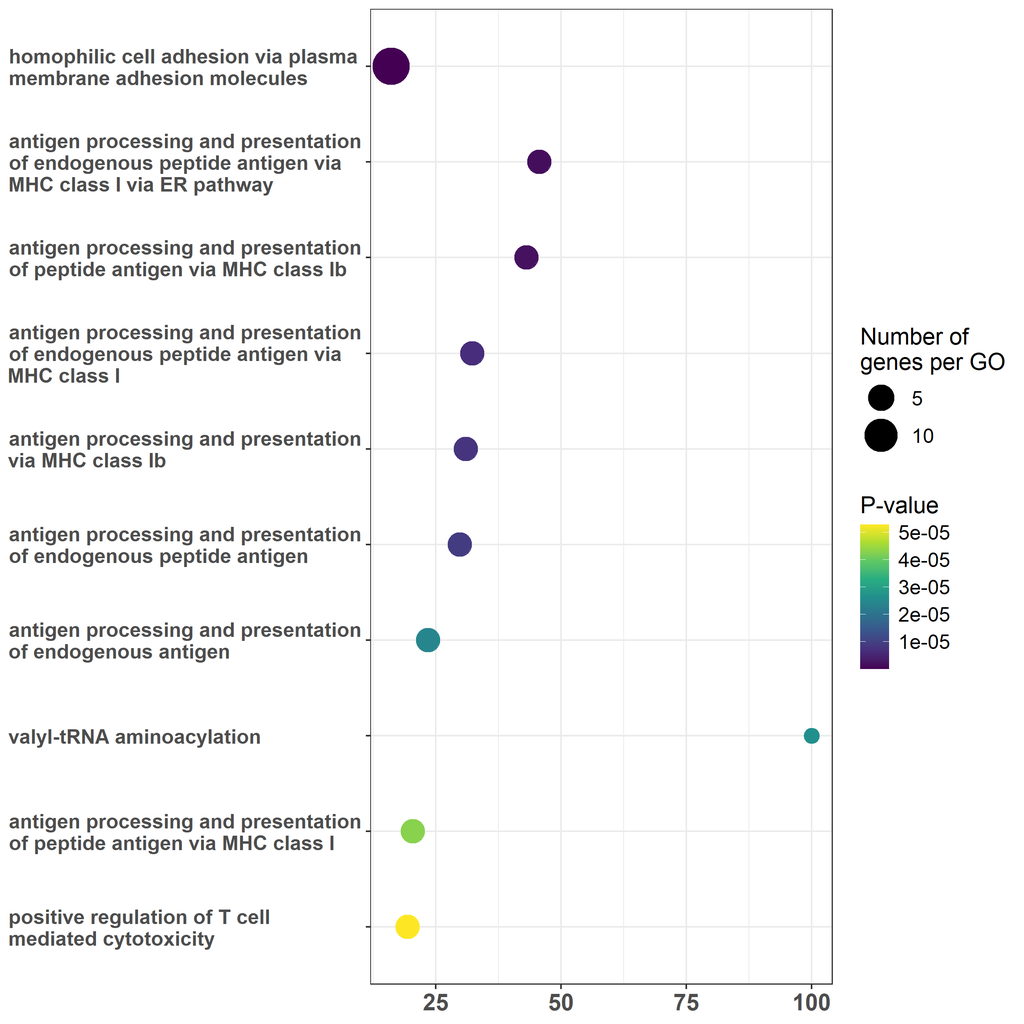

```r
# Figure 3a

fig3a <- ggplot(eqtms_go,
                aes(x = FC,
                    y = reorder(GO, -`P.value`))) +
  geom_point(aes(color = `P.value`,
                 size = noGenes)) +
  scale_size(range = c(4, 10)) +
  scale_color_gradientn(colours = viridis(9)) +
  scale_y_discrete(labels = function(x) str_wrap(x, width = 35)) +
  labs(x=NULL,
       y=NULL,
       color='P-value',
       size='Number of \ngenes per GO'
  ) +
  theme_bw() +
  theme(
    axis.title = element_text(face = 'bold'),
    axis.text.x = element_text(face = 'bold',
                               size = 14),
    axis.text.y = element_text(face = 'bold',
                               size = 12,
                               hjust = -0.005),
    legend.text = element_text(size = 12),
    legend.title = element_text(size = 14)
  )

print(fig3a)
```

## 0.19 Figure 3b

Observed effects of CpGs (in terms of increase in methylation) on the expression of T1D susceptibility genes (positive or negative association) according to cis-eQTM data and effects on gene expression based on changes in methylation of the corresponding CpGs associated with exposure to maternal T1D.

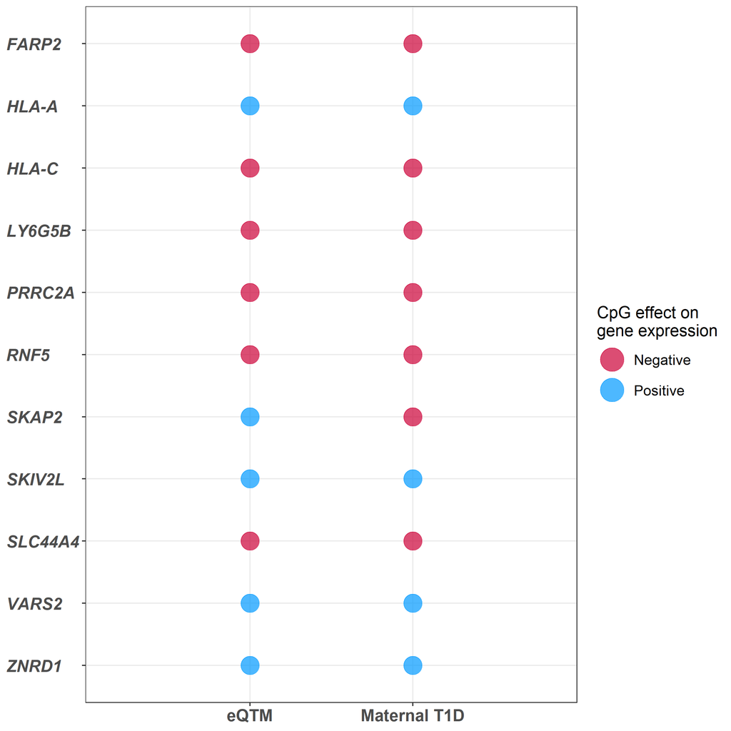

```r
# Figure 3b

color <- c("#CC0036", "#0099FF")

fig3b <-ggplot(eqtms_effects,
               aes(x = Group,
                   y = gene)) +
  geom_point(aes(color = CpG_effect),
             alpha = 0.7,
             size = 7) +
  scale_y_discrete(limits = rev(levels(as.factor(eqtms_effects$gene)))) +
  scale_x_discrete(expand = c(0.01, 1)) +
  scale_color_manual(values = c(color)) +
  labs(x = NULL,
       y = NULL,
       size = NULL,
       color = 'CpG effect on \ngene expression') +
  theme_bw() +
  theme(
    legend.text = element_text(size = 12),
    legend.title = element_text(size = 14),
    axis.text.y = element_text(size = 14,
                               face = "bold.italic",
                               hjust = -0.01),
    axis.text.x = element_text(size = 14,
                               face = "bold"),
  ) +
  guides(color = guide_legend(override.aes = list(size = 9)))

print(fig3b)
```

## 0.20 Figure 4

Maternal T1D methylation propensity score (MPS) links combined CpG methylation to islet autoimmunity. a, The major steps in generating the two MPSs. b, The MPS based on 34 CpGs linked to T1D susceptibility loci by maternal T1D status (ntotal = 1,752, n children with a mother with T1D = 789). c, The MPS based on 426 CpGs not linked to T1D susceptibility loci by maternal T1D status (ntotal = 1,752, n children with a mother with T1D = 789). d, The MPS based on 34 CpGs linked to T1D susceptibility loci in children not exposed to maternal T1D by islet autoimmunity outcome (ntotal = 963, n children who developed islet autoimmunity = 81). e, Forest plot of the variables used in logistic regression models between the MPS based on 34 CpGs linked to T1D susceptibility loci and the islet autoimmunity outcome in children not exposed to maternal T1D. f, The MPS based on 34 CpGs linked to T1D susceptibility loci in children with a father and/or sibling with T1D by islet autoimmunity outcome (ntotal = 604, n children who developed islet autoimmunity = 58). g, The MPS based on 34 CpGs linked to T1D susceptibility loci in children without a first-degree relative with T1D by islet autoimmunity outcome (ntotal = 359, n children who developed islet autoimmunity = 23). h, Validation of the MPS based on 34 CpGs linked to T1D susceptibility loci in children without a mother with T1D from an independent cohort (Fr1da) by islet autoimmunity outcome (ntotal = 303, n children who developed islet autoimmunity = 161). i, The MPS based on 426 CpGs not linked to T1D susceptibility loci in children not exposed to maternal T1D by islet autoimmunity outcome (ntotal = 963, n children who developed islet autoimmunity = 81). Box-plots indicate the median and the 25th and 75th percentile. P-values derived from adjusted logistic regression.

## 0.21 Figure 4a (created in Inkscape)

The major steps in generating the two MPSs (please refer to manuscript).

## 0.22 Figure 4b

The MPS based on 34 CpGs linked to T1D susceptibility loci by maternal T1D status (ntotal = 1,752, n children with a mother with T1D = 789).

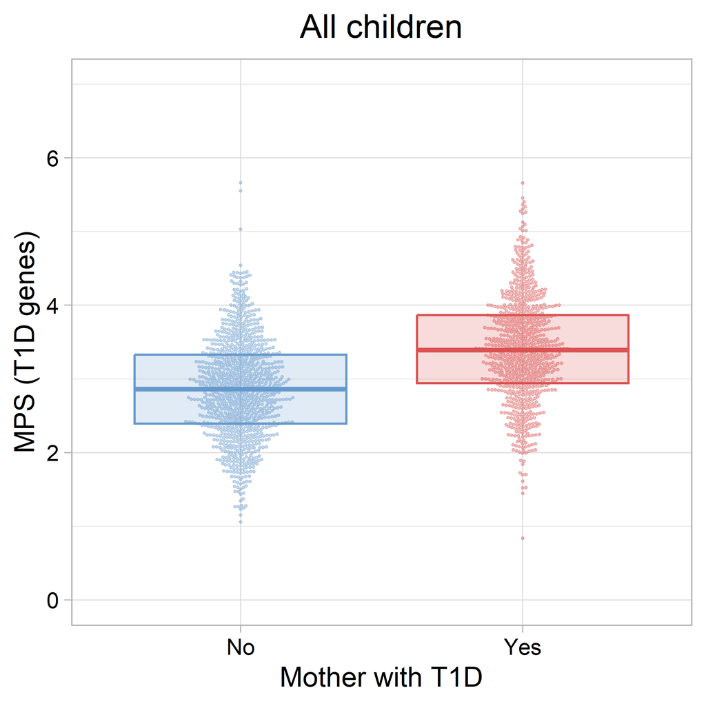

```r
# Figure 4b

color<-c("#6699CC", "#DB5252")
alpha_color <- 1
alpha_fill <- 0.2

fig4b <- ggplot(fig4b_data,
                aes(x = motherT1D,
                    y = MPS)) +
  geom_boxplot(aes(color = motherT1D,
                   fill = motherT1D),
               outlier.shape = NA,
               coef=0,
               show.legend = FALSE,
               linewidth = 1) +
  geom_beeswarm(aes(color = motherT1D),
                alpha = 0.4,
                cex = 0.6,
                show.legend = FALSE,
                size = 1) +
  scale_color_manual(breaks = c("No", "Yes"),
                     values = ggplot2::alpha(color,
                                             alpha_color)) +
  scale_fill_manual(breaks = c("No", "Yes"),
                    values = ggplot2::alpha(color,
                                            alpha_fill)) +
  scale_y_continuous(limits = c(0, 7),
                     breaks = c(0, 2, 4, 6)) +
  theme_light(base_size = 24) +
  theme(axis.text = element_text(colour = "black"),
        plot.title = element_text(hjust = 0.5)) +
  ylab("MPS (T1D genes)") +
  xlab("Mother with T1D") +
  ggtitle("All children")

print(fig4b)
```

## 0.23 Figure 4c

The MPS based on 426 CpGs not linked to T1D susceptibility loci by maternal T1D status (ntotal = 1,752, n children with a mother with T1D = 789).

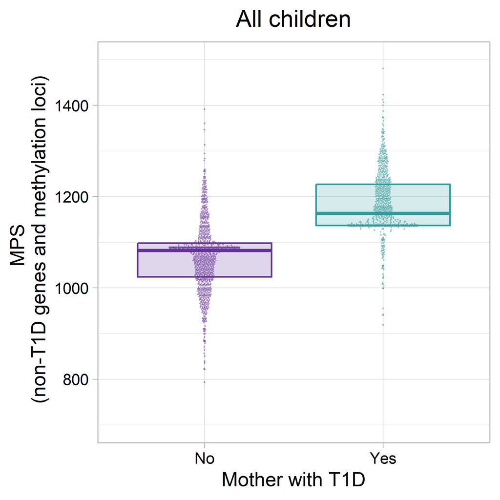

```r
# Figure 4c

color<-c("#663399", "#339999")
alpha_color <- 1
alpha_fill <- 0.2

# plot the scores by maternal T1D
fig4c <- ggplot(fig4c_data,
                aes(x = motherT1D,
                    y = MPS)) +
  geom_boxplot(aes(color = motherT1D,
                   fill = motherT1D),
               outlier.shape = NA,
               coef=0,
               show.legend = FALSE,
               linewidth = 1) +
  geom_quasirandom(aes(color = motherT1D),
                   width = 0.2,
                   alpha = 0.4,
                   cex = 0.6,
                   size = 1,
                   show.legend = FALSE) +
  scale_color_manual(breaks = c("No", "Yes"),
                     values = ggplot2::alpha(color,
                                             alpha_color)) +
  scale_fill_manual(breaks = c("No", "Yes"),
                    values = ggplot2::alpha(color,
                                            alpha_fill)) +
  scale_y_continuous(limits = c(700, 1500),
                     breaks = c(800, 1000, 1200, 1400)) +
  theme_light(base_size = 24) +
  theme(axis.text = element_text(colour = "black"),
        plot.title = element_text(hjust = 0.5)) +
  ylab("MPS \n (non-T1D genes and methylation loci)") +
  xlab("Mother with T1D") +
  ggtitle("All children")

print(fig4c)
```

## 0.24 Figure 4d

The MPS based on 34 CpGs linked to T1D susceptibility loci in children not exposed to maternal T1D by islet autoimmunity outcome (ntotal = 963, n children who developed islet autoimmunity = 81).

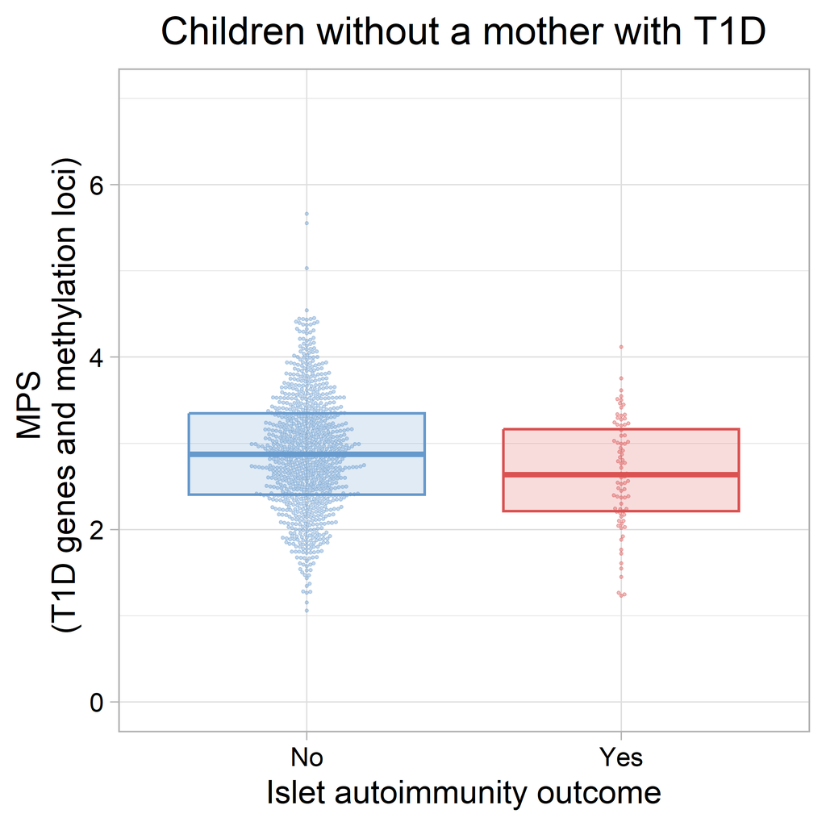

```r
# Figure 4d

color<-c("#6699CC", "#DB5252")
alpha_color <- 1
alpha_fill <- 0.2

fig4d <- ggplot(fig4d_data,
                aes(x = IA_outcome,
                    y = MPS)) +
  geom_boxplot(aes(color = IA_outcome,
                   fill = IA_outcome),
               outlier.shape = NA,
               coef=0,
               show.legend = FALSE,
               linewidth = 1) +
  geom_beeswarm(aes(color = IA_outcome),
                alpha = 0.4,
                cex = 0.6,
                show.legend = FALSE,
                size = 1) +
  scale_color_manual(breaks = c("No", "Yes"),
                     values = ggplot2::alpha(color,
                                             alpha_color)) +
  scale_fill_manual(breaks = c("No", "Yes"),
                    values = ggplot2::alpha(color,
                                            alpha_fill)) +
  scale_y_continuous(limits = c(0, 7), breaks = c(0, 2, 4, 6)) +
  theme_light(base_size = 24) +
  theme(axis.text = element_text(colour = "black"),
        plot.title = element_text(hjust = 0.5)) +
  ylab("MPS \n (T1D genes and methylation loci)") +
  xlab("Islet autoimmunity outcome") +
  ggtitle("Children without a mother with T1D")

print(fig4d)
```

## 0.25 Figure 4e

Forest plot of the variables used in logistic regression models between the MPS based on 34 CpGs linked to T1D susceptibility loci and the islet autoimmunity outcome in children not exposed to maternal T1D.

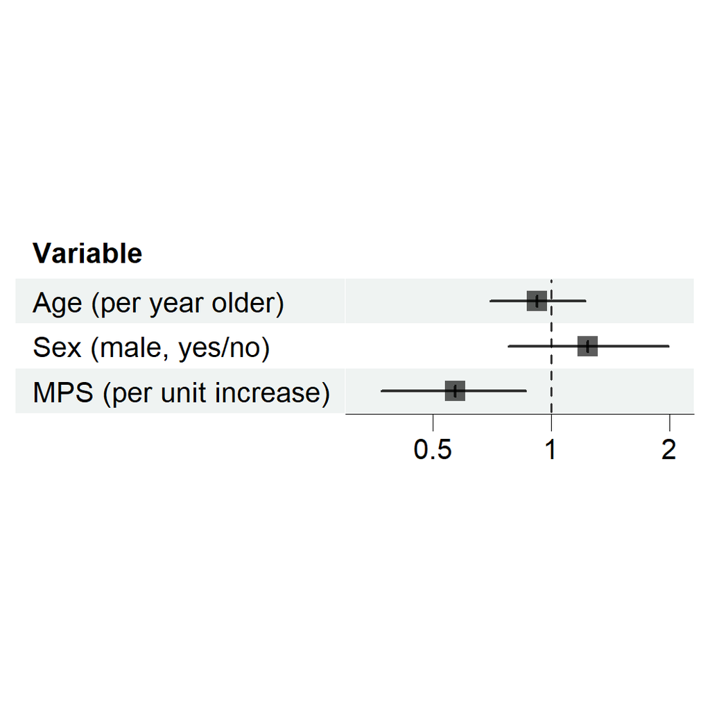

```r
# Figure 4e

tmf <- forest_theme(base_size = 10,
                    ci_pch = 15,
                    ci_alpha = 0.8,
                    ci_lty = 1,
                    ci_lwd = 1.5,
                    refline_lwd = 1,
                    refline_lty = "dashed",
                    refline_col = "grey20")

fig4e <- forest(fig4e_data[,c(2,7)],
                est = fig4e_data$OR,
                lower = fig4e_data$LL,
                upper = fig4e_data$UL,
                sizes = 0.8,
                ci_column = 2,
                x_trans = c("log"),
                xlim = c(0.3, 2.3),
                ticks_at = c(0.5, 1, 2),
                theme = tmf)

print(fig4e)
```

## 0.26 Figure 4f

The MPS based on 34 CpGs linked to T1D susceptibility loci in children with a father and/or sibling with T1D by islet autoimmunity outcome (ntotal = 604, n children who developed islet autoimmunity = 58).

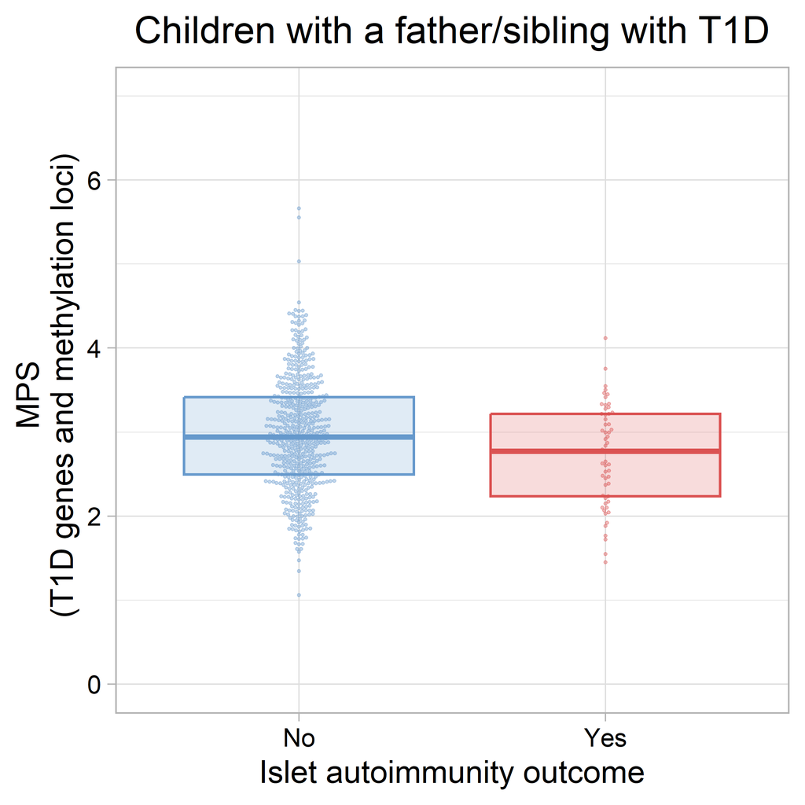

```r
#Figure 4f

color<-c("#6699CC", "#DB5252")
alpha_color <- 1
alpha_fill <- 0.2

fig4f <- ggplot(fig4f_data,
                aes(x = IA_outcome,
                    y = MPS)) +
  geom_boxplot(aes(color = IA_outcome,
                   fill = IA_outcome),
               outlier.shape = NA,
               coef=0,
               show.legend = FALSE,
               linewidth = 1) +
  geom_beeswarm(aes(color = IA_outcome),
                alpha = 0.4,
                cex = 0.6,
                show.legend = FALSE,
                size = 1) +
  scale_color_manual(breaks = c("No", "Yes"),
                     values = ggplot2::alpha(color,
                                             alpha_color)) +
  scale_fill_manual(breaks = c("No", "Yes"),
                    values = ggplot2::alpha(color,
                                            alpha_fill)) +
  scale_y_continuous(limits = c(0, 7),
                     breaks = c(0, 2, 4, 6)) +
  theme_light(base_size = 24) +
  theme(axis.text = element_text(colour="black"),
        plot.title = element_text(hjust = 0.5)) +
  ylab("MPS \n (T1D genes and methylation loci)") +
  xlab("Islet autoimmunity outcome") +
  ggtitle("Children with a father/sibling with T1D")

print(fig4f)
```

## 0.27 Figure 4g

The MPS based on 34 CpGs linked to T1D susceptibility loci in children without a first-degree relative with T1D by islet autoimmunity outcome (ntotal = 359, n children who developed islet autoimmunity = 23).

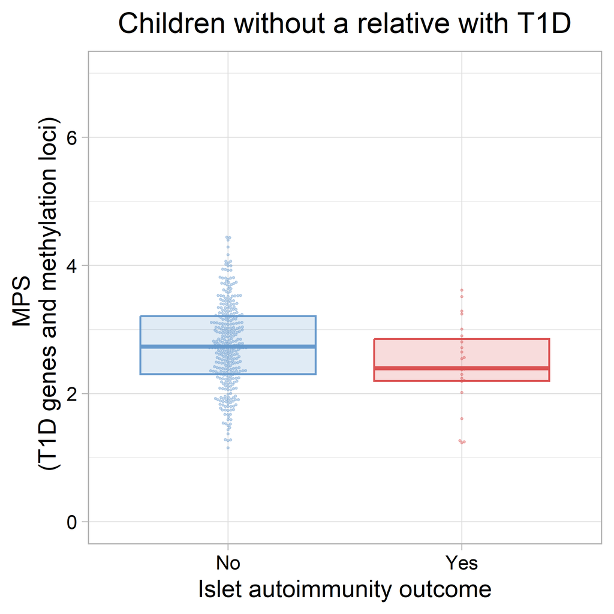

```r
# Figure 4g

color<-c("#6699CC", "#DB5252")
alpha_color <- 1
alpha_fill <- 0.2

fig4g <- ggplot(fig4g_data,
                aes(x = IA_outcome,
                    y = MPS)) +
  geom_boxplot(aes(color = IA_outcome,
                   fill = IA_outcome),
               outlier.shape = NA,
               coef=0,
               show.legend = FALSE,
               linewidth = 1) +
  geom_beeswarm(aes(color = IA_outcome),
                alpha = 0.4,
                cex = 0.6,
                show.legend = FALSE,
                size = 1) +
  scale_color_manual(breaks = c("No", "Yes"),
                     values = ggplot2::alpha(color,
                                             alpha_color)) +
  scale_fill_manual(breaks = c("No", "Yes"),
                    values = ggplot2::alpha(color,
                                            alpha_fill)) +
  scale_y_continuous(limits = c(0, 7),
                     breaks = c(0, 2, 4, 6)) +
  theme_light(base_size = 24) +
  theme(axis.text = element_text(colour = "black"),
        plot.title = element_text(hjust = 0.5)) +
  ylab("MPS \n (T1D genes and methylation loci)") +
  xlab("Islet autoimmunity outcome") +
  ggtitle("Children without a relative with T1D")

print(fig4g)
```

## 0.28 Figure 4h

Validation of the MPS based on 34 CpGs linked to T1D susceptibility loci in children without a mother with T1D from an independent cohort (Fr1da) by islet autoimmunity outcome (ntotal = 303, n children who developed islet autoimmunity = 161).

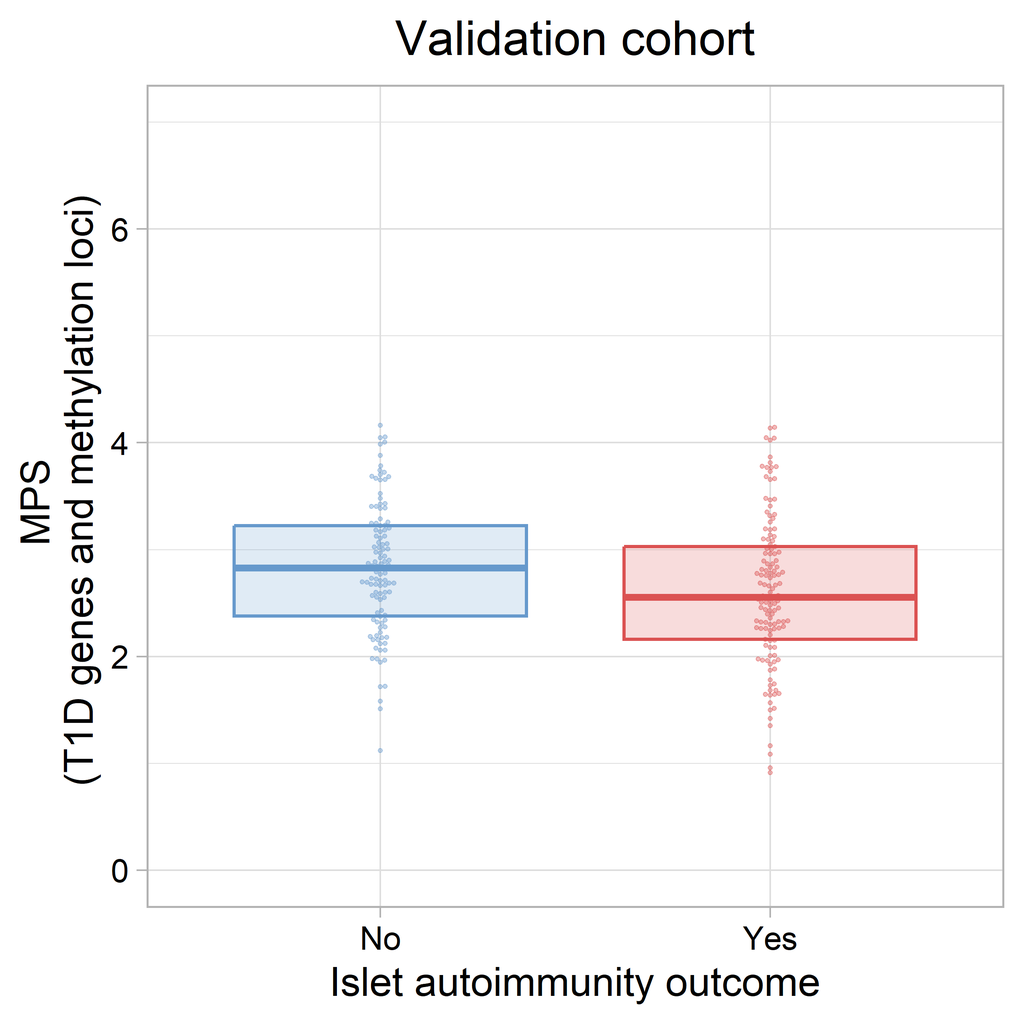

```r
# Figure 4h

color<-c("#6699CC", "#DB5252")
alpha_color <- 1
alpha_fill <- 0.2

fig4h <- ggplot(fig4h_data,
                aes(x = IA_outcome,
                    y = MPS)) +
  geom_boxplot(aes(color = IA_outcome,
                   fill = IA_outcome),
               outlier.shape = NA,
               coef=0,
               show.legend = FALSE,
               linewidth = 1) +
  geom_beeswarm(aes(color = IA_outcome),
                alpha = 0.4,
                cex = 0.6,
                show.legend = FALSE,
                size = 1) +
  scale_color_manual(breaks = c("No", "Yes"),
                     values = ggplot2::alpha(color,
                                             alpha_color)) +
  scale_fill_manual(breaks = c("No", "Yes"),
                    values = ggplot2::alpha(color,
                                            alpha_fill)) +
  scale_y_continuous(limits = c(0, 7),
                     breaks = c(0, 2, 4, 6)) +
  theme_light(base_size = 24) +
  theme(axis.text = element_text(colour = "black"),
        plot.title = element_text(hjust = 0.5)) +
  ylab("MPS \n (T1D genes and methylation loci)") +
  xlab("Islet autoimmunity outcome") +
  ggtitle("Validation cohort")

print(fig4h)
```

## 0.29 Figure 4i

The MPS based on 426 CpGs not linked to T1D susceptibility loci in children not exposed to maternal T1D by islet autoimmunity outcome (ntotal = 963, n children who developed islet autoimmunity = 81).

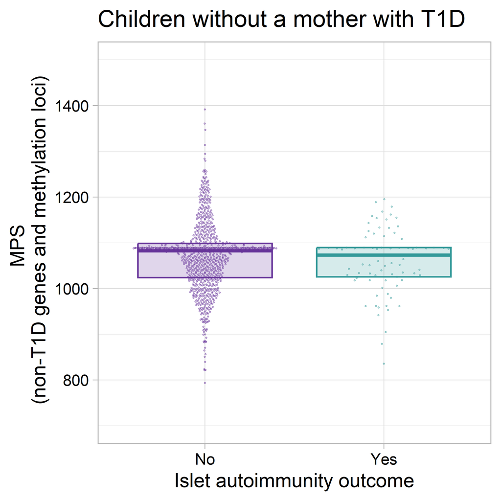

```r
#Figure 4i

color<-c("#663399", "#339999")
alpha_color <- 1
alpha_fill <- 0.2

fig4i <- ggplot(fig4i_data,
                aes(x = IA_outcome,
                    y = MPS)) +
  geom_boxplot(aes(color = IA_outcome,
                   fill = IA_outcome),
               outlier.shape = NA,
               coef = 0,
               show.legend = FALSE,
               linewidth = 1) +
  geom_quasirandom(aes(color = IA_outcome),
                   alpha = 0.4,
                   cex = 0.8,
                   show.legend = FALSE) +
  scale_color_manual(breaks = c("No", "Yes"),
                     values = alpha(color, alpha_color)) +
  scale_fill_manual(breaks = c("No", "Yes"),
                    values = alpha(color, alpha_fill)) +
  scale_y_continuous(limits = c(700, 1500),
                     breaks = c(800, 1000, 1200, 1400)) +
  theme_light(base_size = 24) +
  theme(axis.text = element_text(colour = "black")) +
  ylab("MPS \n (non-T1D genes and methylation loci)") +
  xlab("Islet autoimmunity outcome") +
  ggtitle("Children without a mother with T1D")

print(fig4i)
```

## 0.30 Extended Data Figures

## 0.31 Extended Data Figure 1 (created in Inkscape)

Flow-charts of children included in this study. The flow-charts were created using InkScape.

## 0.32 Extended Data Figure 1d

Scree plot of eigenvalues of the first ten principal components by study. The plot shows the eigenvalues as logarithmic scale of the first ten principal components derived from principal component analysis (PCA) using all 651,271 CpG sites in the BABYDIAB/BABYDIET and POInT studies. The first three principal components covered over 95% of variability and were included into the linear models. An eigenvalue of one is indicated by the horizontal line.

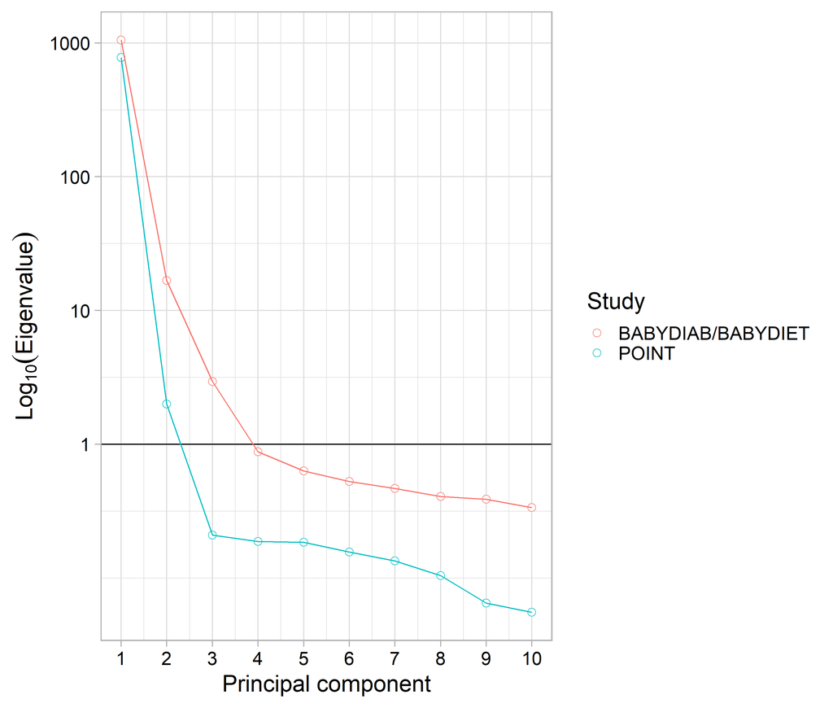

```r
# Extended Data Figure 1d

ExtDataFig1d <- ExtDataFig1d_data %>%
  mutate(across(PC, as.numeric)) %>%
  ggplot( aes(x = PC,
              y = Eigenvalues,
              group = Study,
              color = Study)) +
  geom_hline(yintercept = 1) +
  geom_point(size = 3,
             shape = 21,
             fill = "white") +
  geom_line(aes(x = PC,
                y = Eigenvalues,
                colour = as.factor(Study),
                group = Study,
                linetype = "dashed"),
            show.legend = FALSE) +
  scale_x_continuous(breaks = c(1, 2, 3, 4, 5, 6, 7, 8, 9, 10)) +
  scale_y_log10(breaks = c(1, 10, 100, 1000)) +
  theme_light(base_size = 20) +
  theme(axis.text = element_text(colour = "black")) +
  labs(y = c(expression(Log[10]*(Eigenvalue))),
       x = "Principal component")

print(ExtDataFig1d)
```

## 0.33 Extended Data Figure 2

Validation of maternal T1D offspring-associated CpGs at HOXA5 and T1D susceptibility genes. a, UCSC Genome Browser map (hg19) of the HOXA5 and HOXA6 promoter regions with indicated locations of the presented CpGs at HOXA5. b, Correlation plot showing blood methylation values of maternal T1D associated CpGs at HOXA5 between the Illumina EPIC array and bisulfite pyrosequencing in children (n = 45-74). c-e, Methylation levels at maternal T1D associated CpGs in children with mothers with T1D vs. children with unaffected mothers determined by Illumina EPIC array or bisulfite pyrosequencing (n = 45-74). f, Methylation levels of CpGs near the Illumina EPIC array HOXA5 probes in children with mothers with T1D vs. children with unaffected mothers determined by bisulfite pyrosequencing (n = 45-74). g, Correlation plot showing blood methylation values of maternal T1D associated CpGs linked to T1D susceptibility genes between the Illumina EPIC array and bisulfite pyrosequencing in young children (n = 40-63). h-l, Methylation levels at CpGs linked to T1D susceptibility genes (SKAP2, SLC4A44, LY6G5B, TNXB, SKIV2L) in children with mothers with T1D vs. children with unaffected mothers determined by Illumina EPIC array or bisulfite pyrosequencing (n = 40-63). A schematic regulatory map is shown above each CpG based on the eQTM-derived CpG target genes. Box-plots indicate the median and the 25th and 75th percentile, whiskers extend 1.5 times the IQR from the top and bottom of the box. P-values derived from Welch’s t-test or Mann-Whitney-U test (two-sided).

## 0.34 Extended Data Figure 2a (created in UCSC and Inkscape)

UCSC Genome Browser map (hg19) of the HOXA5 and HOXA6 promoter regions with indicated locations of the presented CpGs.

## 0.35 Extended Data Figure 2b

Correlation plot showing blood methylation values of maternal T1D associated CpGs between the Illumina EPIC array and bisulfite pyrosequencing in children.

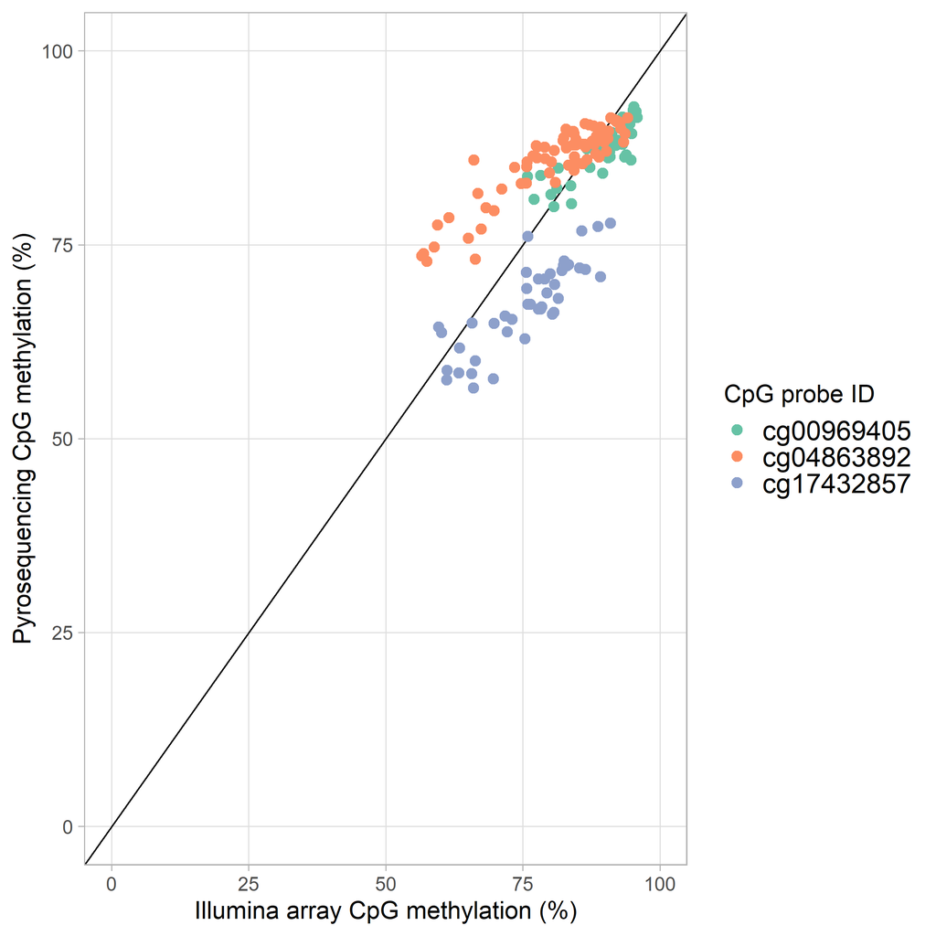

```r
# Extended Data Figure 2b

ExtDataFig2b <- ggplot(ExtDataFig2b_data,
                       aes(x = Array,
                           y = Pyrosequencing,
                           color = CpG)) +
  geom_point(shape = 21) +
  scale_colour_brewer(palette = "Set2") +
  geom_abline(intercept = 0) +
  scale_y_continuous(limits = c(0, 100),
                     breaks = c(0, 25, 50, 75, 100)) +
  scale_x_continuous(limits = c(0, 100),
                     breaks = c(0, 25, 50, 75, 100)) +
  theme_light(base_size = 16) +
  theme(panel.grid.minor = element_blank(),
        legend.text = element_text(size = rel(1.1))) +
  labs(x = "Illumina array CpG methylation (%)",
       y = "Pyrosequencing CpG methylation (%)",
       color = "CpG probe ID")

jit <- position_jitter(seed = 123)

ExtDataFig2b + geom_jitter(aes(color = CpG),
                           size = 3,
                           position = jit)
```

## 0.36 Extended Data Figure 2c

Methylation levels at maternal T1D associated CpGs in children with mothers with T1D vs. children with unaffected mothers determined by Illumina EPIC array or bisulfite pyrosequencing.

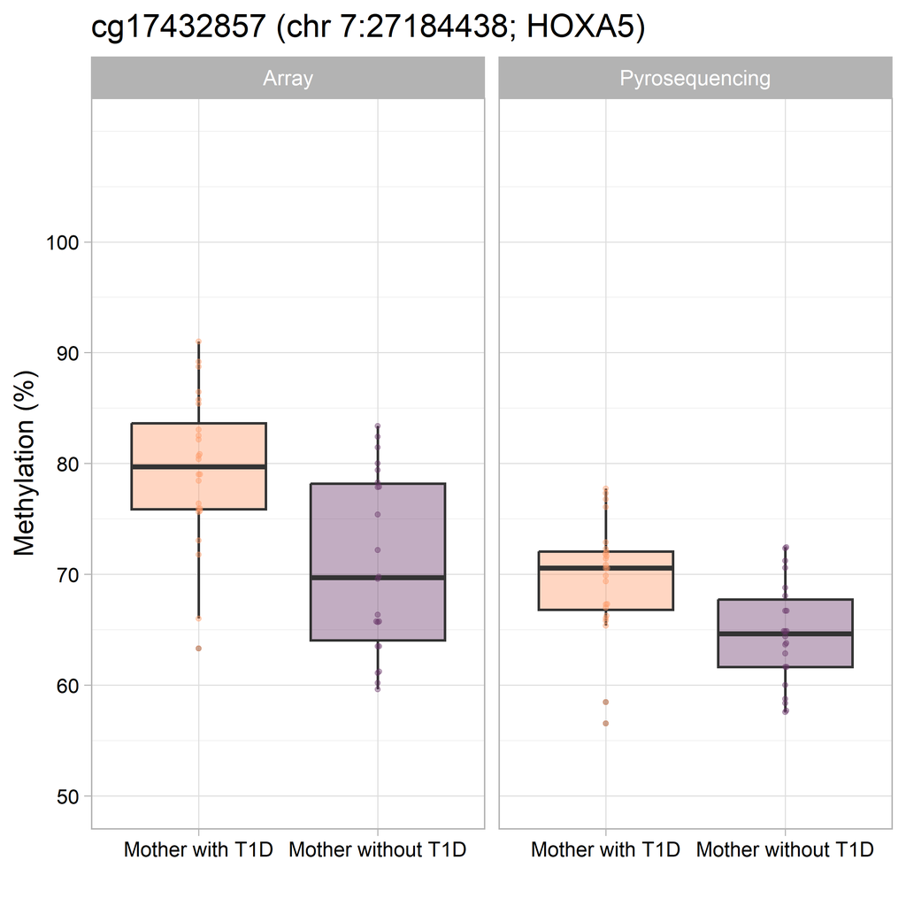

```r
# Extended Data Figure 2c

color<-c("#663366", "#FF9966")
alpha_color <- 1
alpha_fill <- 0.9

ExtDataFig2c <- ggplot(ExtDataFig2c_data,
                       aes(x = factor(group),
                           y = cg17432857)) +
  geom_boxplot(aes(fill = factor(group)),
               alpha = 0.4,
               cex = 0.8,
               show.legend = FALSE) +
  geom_beeswarm(aes(color = factor(group)),
                alpha = 0.4,
                cex = 0.4,
                show.legend = FALSE,
                size = 1.5) +
  scale_color_manual(breaks = c("Mother without T1D", "Mother with T1D"),
                     values = alpha(color, alpha_color)) +
  scale_fill_manual(breaks = c("Mother without T1D", "Mother with T1D"),
                    values = alpha(color, alpha_fill)) +
  theme_light(base_size = 18) +
  theme(axis.text = element_text(size = 14,
                                 colour = "black"))+
  scale_y_continuous(limits = c(50,110),
                     breaks = c(50,60,70,80,90,100)) +
  labs(title = "cg17432857 (chr 7:27184438; HOXA5)",
       x = "",
       y = "Methylation (%)") +
  facet_wrap(~analysis,
             ncol = 2)

print(ExtDataFig2c)
```

## 0.37 Extended Data Figure 2d

Methylation levels at maternal T1D associated CpGs in children with mothers with T1D vs. children with unaffected mothers determined by Illumina EPIC array or bisulfite pyrosequencing.

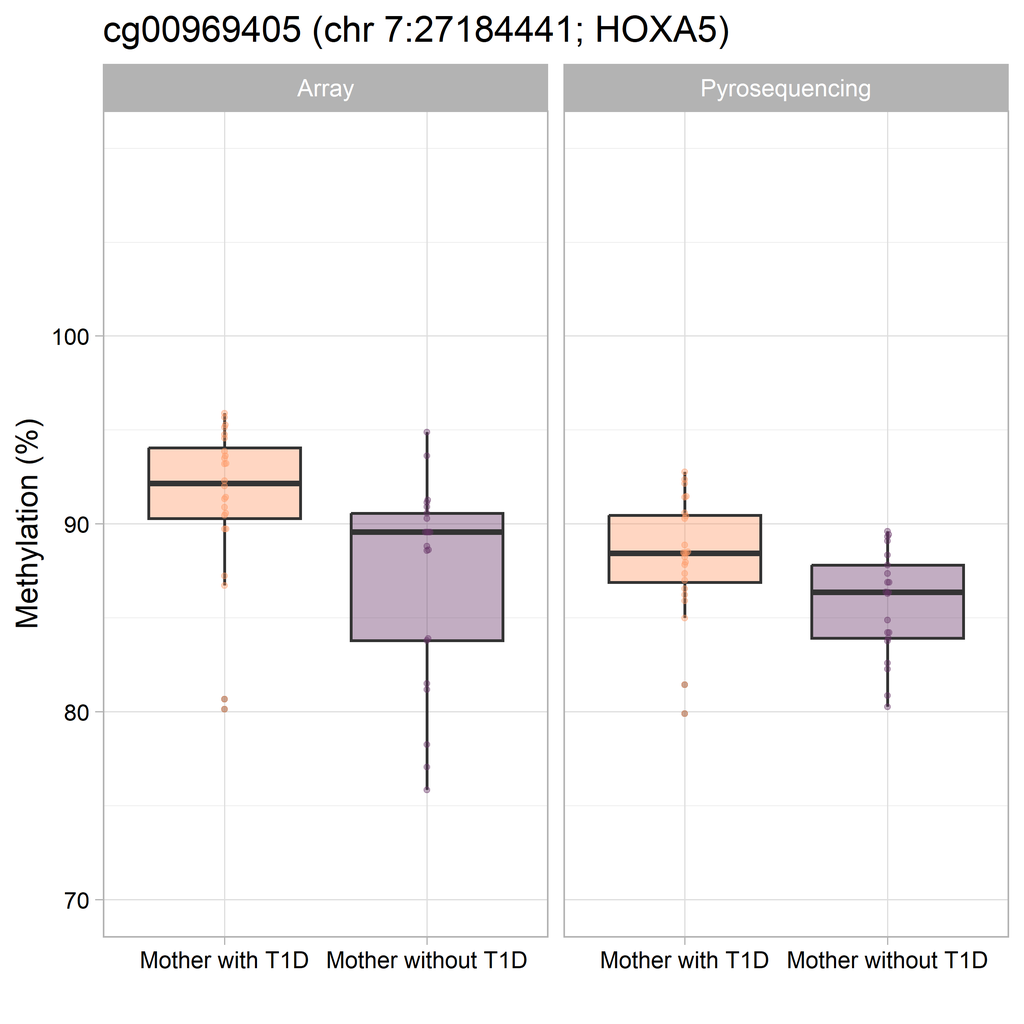

```r
# Extended Data Figure 2d

color<-c("#663366", "#FF9966")
alpha_color <- 1
alpha_fill <- 0.9

ExtDataFig2d <- ggplot(ExtDataFig2d_data,
                       aes(x = factor(group),
                           y = cg00969405)) +
  geom_boxplot(aes(fill = factor(group)),
               alpha = 0.4,
               cex = 0.8,
               show.legend = FALSE) +
  geom_beeswarm(aes(color = factor(group)),
                alpha = 0.4,
                cex = 0.4,
                show.legend = FALSE,
                size = 1.5) +
  scale_color_manual(breaks = c("Mother without T1D", "Mother with T1D"),
                     values = alpha(color, alpha_color)) +
  scale_fill_manual(breaks = c("Mother without T1D", "Mother with T1D"),
                    values = alpha(color, alpha_fill)) +
  theme_light(base_size = 18) +
  theme(axis.text = element_text(size = 14,
                                 colour = "black")) +
  scale_y_continuous(limits = c(70,110),
                     breaks = c(70,80,90,100)) +
  labs(title = "cg00969405 (chr 7:27184441; HOXA5)",
       x = "",
       y = "Methylation (%)") +
  facet_wrap(~analysis,
             ncol = 2)

print(ExtDataFig2d)
```

## 0.38 Extended Data Figure 2e

Methylation levels at maternal T1D associated CpGs in children with mothers with T1D vs. children with unaffected mothers determined by Illumina EPIC array or bisulfite pyrosequencing.

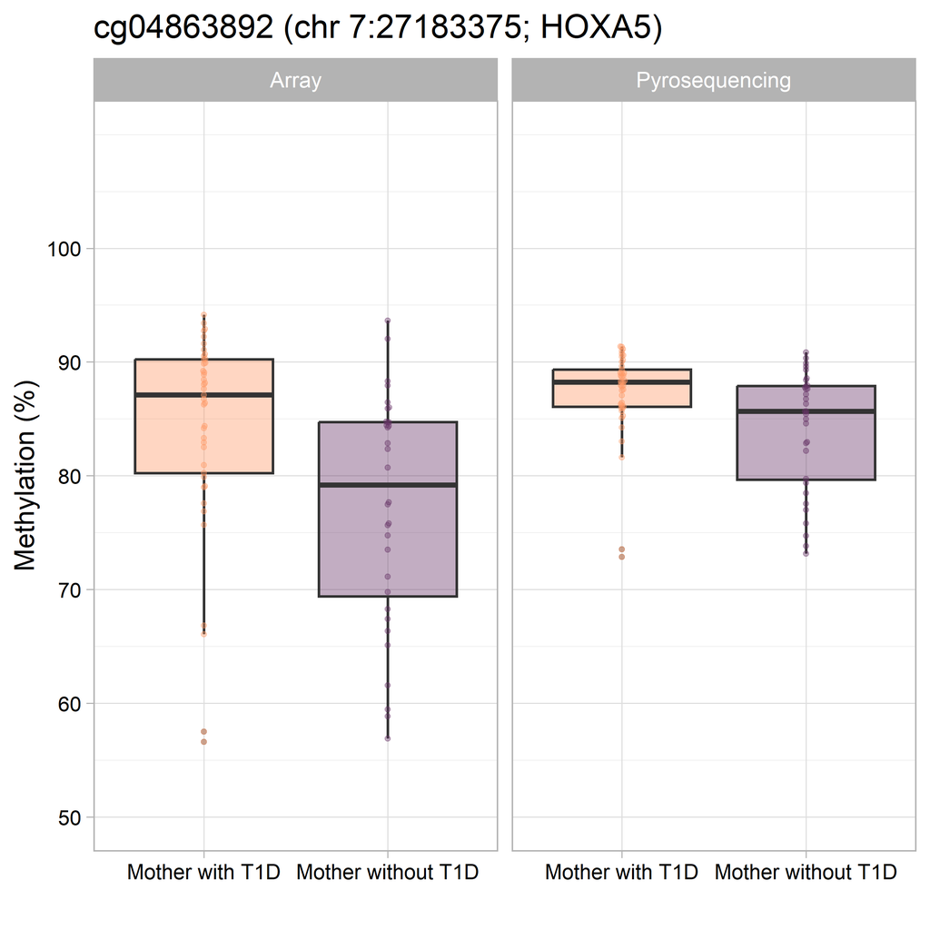

```r
# Extended Data Figure 2e

color<-c("#663366", "#FF9966")
alpha_color <- 1
alpha_fill <- 0.9

ExtDataFig2e <- ggplot(ExtDataFig2e_data,
                       aes(x = factor(group),
                           y = cg04863892)) +
  geom_boxplot(aes(fill = factor(group)),
               alpha = 0.4,
               cex = 0.8,
               show.legend = FALSE) +
  geom_beeswarm(aes(color = factor(group)),
                alpha = 0.4,
                cex = 0.4,
                show.legend = FALSE,
                size = 1.5) +
  scale_color_manual(breaks = c("Mother without T1D", "Mother with T1D"),
                     values = alpha(color, alpha_color)) +
  scale_fill_manual(breaks = c("Mother without T1D", "Mother with T1D"),
                    values = alpha(color, alpha_fill)) +
  theme_light(base_size = 18) +
  theme(axis.text = element_text(size = 14,
                                 colour = "black"))+
  scale_y_continuous(limits = c(50,110),
                     breaks = c(50,60,70,80,90,100)) +
  labs(title = "cg04863892 (chr 7:27183375; HOXA5)",
       x = "",
       y = "Methylation (%)") +
  facet_wrap(~analysis,
             ncol = 2)

print(ExtDataFig2e)
```

## 0.39 Extended Data Figure 2f

Methylation levels of CpGs near the Illumina EPIC array HOXA5 probes in children with mothers with T1D vs. children with unaffected mothers determined by bisulfite pyrosequencing.

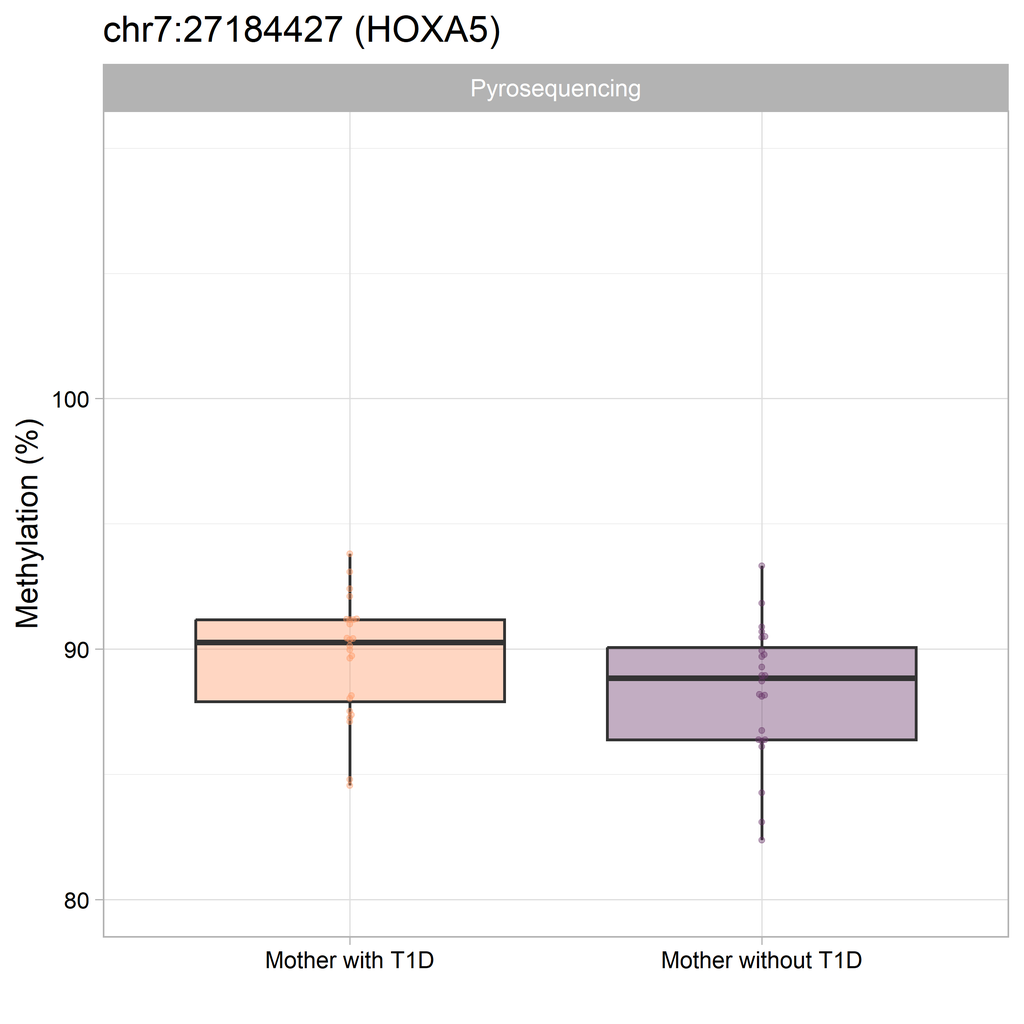

```r
# Extended Data Figure 2f1

color<-c("#663366", "#FF9966")
alpha_color <- 1
alpha_fill <- 0.9

ExtDataFig2f1 <- ggplot(ExtDataFig2f1_data,
                       aes(x = factor(group),
                           y = `chr7_27184427`)) +
  geom_boxplot(aes(fill = factor(group)),
               alpha = 0.4,
               cex = 0.8,
               show.legend = FALSE) +
  geom_beeswarm(aes(color = factor(group)),
                alpha = 0.4,
                cex = 0.4,
                show.legend = FALSE,
                size = 1.5) +
  scale_color_manual(breaks = c("Mother without T1D", "Mother with T1D"),
                     values = alpha(color, alpha_color)) +
  scale_fill_manual(breaks = c("Mother without T1D", "Mother with T1D"),
                    values = alpha(color, alpha_fill)) +
  theme_light(base_size = 18) +
  theme(axis.text = element_text(size = 14,
                                 colour = "black"))+
  scale_y_continuous(limits = c(80,110),
                     breaks = c(70,80,90,100)) +
  labs(title = "chr7:27184427 (HOXA5)",
       x = "",
       y = "Methylation (%)") +
  facet_wrap(~analysis,
             ncol = 2)

print(ExtDataFig2f1)
```

## 0.40 Extended Data Figure 2f

Methylation levels of CpGs near the Illumina EPIC array HOXA5 probes in children with mothers with T1D vs. children with unaffected mothers determined by bisulfite pyrosequencing.

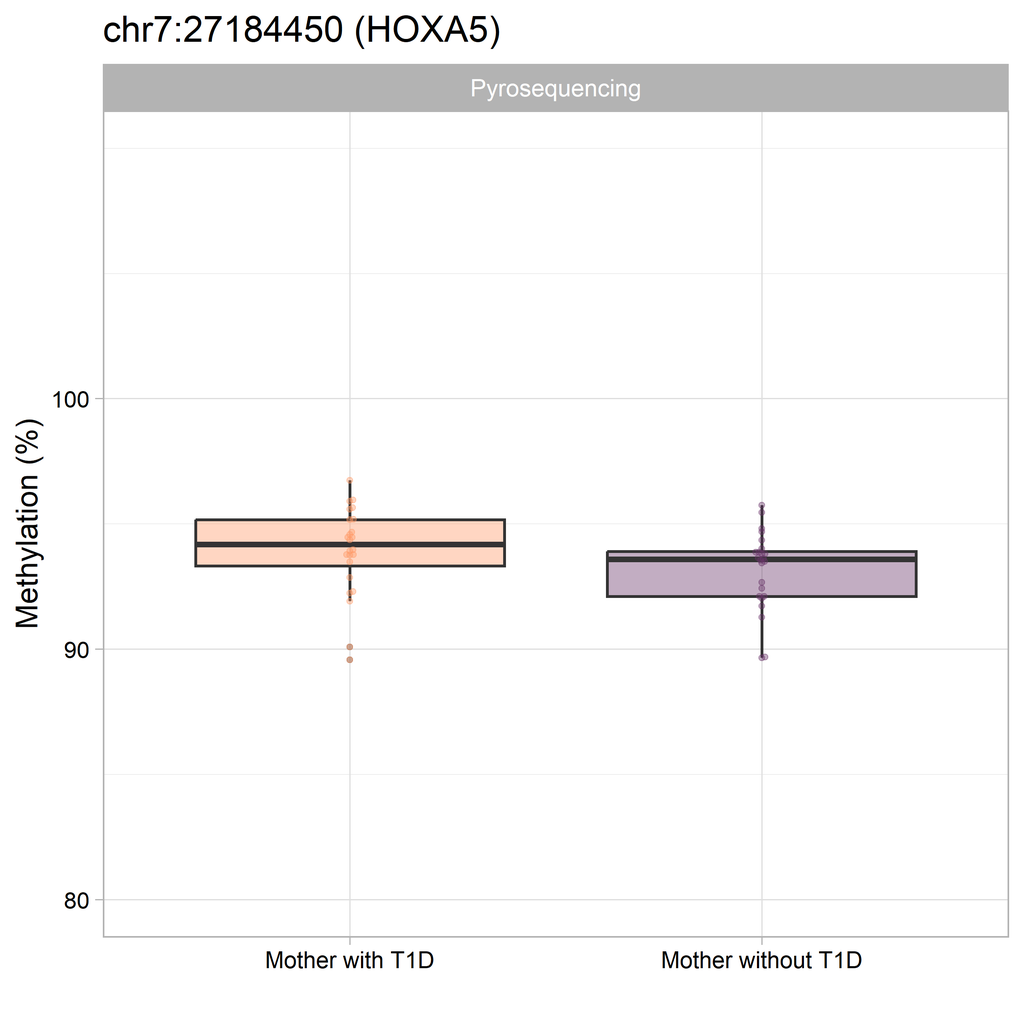

```r
# Extended Data Figure 2f2

color<-c("#663366", "#FF9966")
alpha_color <- 1
alpha_fill <- 0.9

ExtDataFig2f2 <- ggplot(ExtDataFig2f2_data,
                       aes(x = factor(group),
                           y = `chr7_27184450`)) +
  geom_boxplot(aes(fill = factor(group)),
               alpha = 0.4,
               cex = 0.8,
               show.legend = FALSE) +
  geom_beeswarm(aes(color = factor(group)),
                alpha = 0.4,
                cex = 0.4,
                show.legend = FALSE,
                size = 1.5) +
  scale_color_manual(breaks = c("Mother without T1D", "Mother with T1D"),
                     values = alpha(color, alpha_color)) +
  scale_fill_manual(breaks = c("Mother without T1D", "Mother with T1D"),
                    values = alpha(color, alpha_fill)) +
  theme_light(base_size = 18) +
  theme(axis.text = element_text(size = 14,
                                 colour = "black"))+
  scale_y_continuous(limits = c(80,110),
                     breaks = c(60,70,80,90,100)) +
  labs(title = "chr7:27184450 (HOXA5)",
       x = "",
       y = "Methylation (%)") +
  facet_wrap(~analysis,
             ncol = 2)

print(ExtDataFig2f2)
```

## 0.41 Extended Data Figure 2f

Methylation levels of CpGs near the Illumina EPIC array HOXA5 probes in children with mothers with T1D vs. children with unaffected mothers determined by bisulfite pyrosequencing.

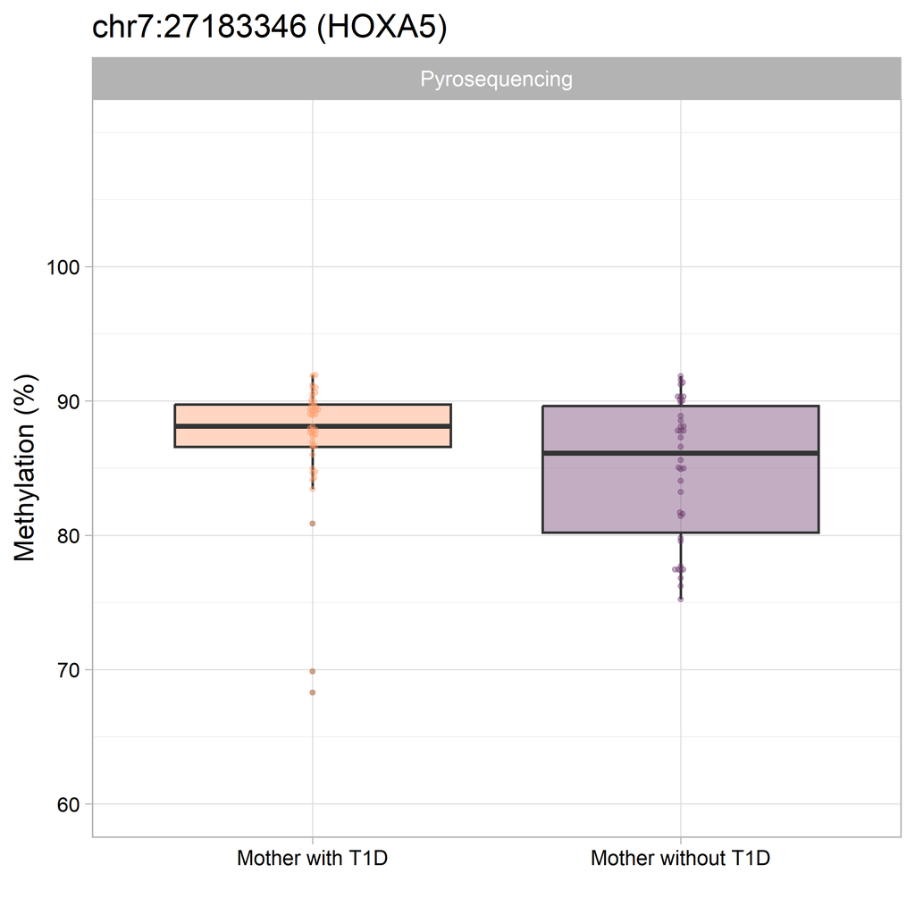

```r
# Extended Data Figure 2f3

color<-c("#663366", "#FF9966")
alpha_color <- 1
alpha_fill <- 0.9

ExtDataFig2f3 <- ggplot(ExtDataFig2f3_data,
                       aes(x = factor(group),
                           y = `chr7_27183346`)) +
  geom_boxplot(aes(fill = factor(group)),
               alpha = 0.4,
               cex = 0.8,
               show.legend = FALSE) +
  geom_beeswarm(aes(color = factor(group)),
                alpha = 0.4,
                cex = 0.4,
                show.legend = FALSE,
                size = 1.5) +
  scale_color_manual(breaks = c("Mother without T1D", "Mother with T1D"),
                     values = alpha(color, alpha_color)) +
  scale_fill_manual(breaks = c("Mother without T1D", "Mother with T1D"),
                    values = alpha(color, alpha_fill)) +
  theme_light(base_size = 18) +
  theme(axis.text = element_text(size = 14,
                                 colour = "black")) +
  scale_y_continuous(limits = c(60,110),
                     breaks = c(60,70,80,90,100)) +
  labs(title = "chr7:27183346 (HOXA5)",
       x = "",
       y = "Methylation (%)") +
  facet_wrap(~analysis,
             ncol = 2)

print(ExtDataFig2f3)
```

## 0.42 Extended Data Figure 2f

Methylation levels of CpGs near the Illumina EPIC array HOXA5 probes in children with mothers with T1D vs. children with unaffected mothers determined by bisulfite pyrosequencing.

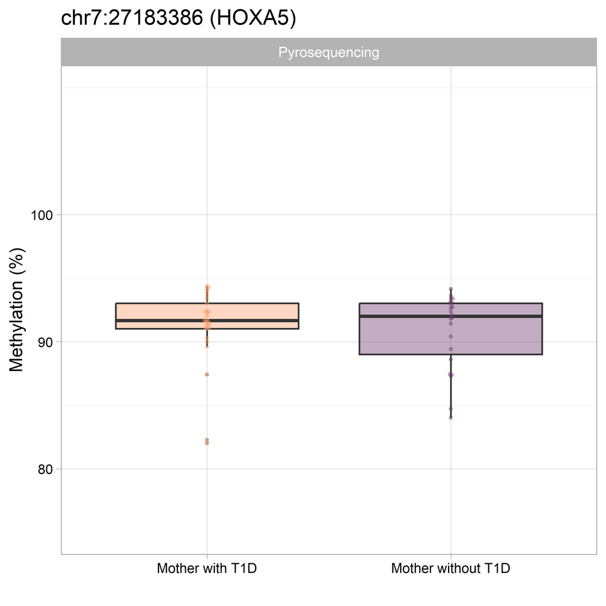

```r
# Extended Data Figure 2f

color<-c("#663366", "#FF9966")
alpha_color <- 1
alpha_fill <- 0.9

ExtDataFig2f4 <- ggplot(ExtDataFig2f4_data,
                       aes(x = factor(group),
                           y = `chr7_27183386`)) +
  geom_boxplot(aes(fill = factor(group)),
               alpha = 0.4,
               cex = 0.8,
               show.legend = FALSE) +
  geom_beeswarm(aes(color = factor(group)),
                alpha = 0.4,
                cex = 0.4,
                show.legend = FALSE,
                size = 1.5) +
  scale_color_manual(breaks = c("Mother without T1D", "Mother with T1D"),
                     values = alpha(color, alpha_color)) +
  scale_fill_manual(breaks = c("Mother without T1D", "Mother with T1D"),
                    values = alpha(color, alpha_fill)) +
  theme_light(base_size = 18) +
  theme(axis.text = element_text(size = 14,
                                 colour = "black"))+
  scale_y_continuous(limits = c(75,110),
                     breaks = c(40,60,80,90,100)) +
  labs(title = "chr7:27183386 (HOXA5)",
       x = "",
       y = "Methylation (%)") +
  facet_wrap(~analysis,
             ncol = 2)

print(ExtDataFig2f4)
```